# Ecological state of macrozoobenthic communities - Burgas Bay

2019-05-25

This notebook contains the assessment and analysis of ecological state of macrozoobenthic communities in Burgas Bay (2013-14). The selected indices and statistics are the ones used for the national monitoring and assessments of soft bottom macrozoobenthos - H’, AMBI, M-AMBI (both classical and simplified), and BENTIX - used in the Eastern Mediterranean (mostly Greece).

Setup!

Define the working subdirectories.

```r
## print the working directory, just to be on the safe side
paste("You are here: ", getwd())
```

```
[1] "You are here:  /media/sklayn/data/data/rabota/documents/phd/thesis/4-results-discussion/data-n-analyses/results-analysis"
```

```r
data.dir <- "data"    ## input data files
functions.dir <- "R"  ## functions & scripts
save.dir <- "output"  ## clean data, output from models & more complex calculations
figures.dir <- "figs" ## plots & figures
```

Import libraries.

```r
library(here) ## painless relative paths to subdurectories, etc.
```

```r
## NB these two import MASS, which masks dplyr::select - and I use the latter extensively, so I prefer it to be on top..
library(sandwich) ## robust regression and corrections for multiple comparisons of means.
library(multcomp) ## robust regression and corrections for multiple comparisons of means
```

```r
library(tidyverse) ## data manipulation, cleaning, aggregation
```

```r
library(viridis) ## smart & pretty colour schemes
```

Import custom functions for index and EQR calculations, and for performance comparisons.

```r
source(here(functions.dir, "mambi_sigovini.R"))
source(here(functions.dir, "bentix.R"))
source(here(functions.dir, "eqr.R"))
source(here(functions.dir, "indices_intercalibration.R"))
```

Organize some commonly-used ggplot2 modifications into a more convenient (and less repetitive) format. One day, I MUST figure out the proper way to set the theme..

```r
## ggplot settings & things that I keep reusing
# ggplot_theme <- list(
#   theme_bw(),
#   theme(element_text(family = "Times"))
# )

## always use black-and-white theme
theme_set(theme_bw())

## helper to adjust ggplot text size & avoid repetitions
text_size <- function(text.x = NULL,
                      text.y = NULL,
                      title.x = NULL,
                      title.y = NULL,
                      legend.text = NULL,
                      legend.title = NULL,
                      strip.x = NULL,
                      strip.y = NULL) {
  theme(axis.text.x = element_text(size = text.x),
        axis.text.y = element_text(size = text.y),
        axis.title.x = element_text(size = title.x),
        axis.title.y = element_text(size = title.y),
        legend.text = element_text(size = legend.text),
        legend.title = element_text(size = legend.title),
        strip.text.x = element_text(size = strip.x),
        strip.text.y = element_text(size = strip.y)
        )
}
```

#### **Sand stations (Burgas Bay, 2013-2014)**

Import zoobenthic abundance data (cleaned and prepared).

| station | month | year | habitat | replicate | biotope | Abra alba | Abra prismatica | Abra segmentum | Abra sp. | Acanthocardia tuberculata | Acari | Actiniaria | Alitta succinea | Ampelisca diadema | Ampharetidae | Amphibalanus improvisus | Amphipoda | Amphitritides gracilis | Ampithoe sp. | Anadara kagoshimensis | Aonides paucibranchiata | Apherusa bispinosa | Apseudopsis ostroumovi | Aricidea claudiae | Bathyporeia guilliamsoniana | Bittium reticulatum | Bivalvia undet. | Bodotria arenosa | Brachynotus sexdentatus | … |
| --- | --- | --- | --- | --- | --- | --- | --- | --- | --- | --- | --- | --- | --- | --- | --- | --- | --- | --- | --- | --- | --- | --- | --- | --- | --- | --- | --- | --- | --- | --- |
| Kraimorie | 6 | 2013 | S | a | ILitMMelin | 11 | 0 | 0 | 0 | 0 | 0 | 0 | 2 | 6 | 0 | 3 | 0 | 0 | 0 | 1 | 0 | 0 | 0 | 0 | 0 | 38 | 0 | 0 | 0 | … |
| Kraimorie | 6 | 2013 | S | b | ILitMMelin | 5 | 0 | 0 | 0 | 0 | 0 | 0 | 0 | 4 | 0 | 0 | 0 | 0 | 0 | 8 | 0 | 0 | 0 | 0 | 0 | 17 | 0 | 0 | 1 | … |
| Kraimorie | 6 | 2013 | S | c | ILitMMelin | 8 | 0 | 0 | 0 | 0 | 0 | 0 | 0 | 0 | 0 | 1 | 0 | 0 | 0 | 5 | 0 | 0 | 0 | 0 | 0 | 22 | 0 | 0 | 0 | … |
| Kraimorie | 9 | 2013 | S | a | ILitMMelin | 5 | 0 | 0 | 0 | 0 | 0 | 0 | 3 | 2 | 0 | 0 | 0 | 0 | 0 | 12 | 0 | 0 | 0 | 1 | 0 | 10 | 0 | 0 | 0 | … |
| Kraimorie | 9 | 2013 | S | b | ILitMMelin | 1 | 0 | 0 | 0 | 0 | 0 | 0 | 2 | 0 | 0 | 1 | 0 | 0 | 0 | 5 | 0 | 0 | 0 | 0 | 0 | 5 | 0 | 0 | 0 | … |
| Kraimorie | 9 | 2013 | S | c | ILitMMelin | 2 | 0 | 0 | 0 | 0 | 0 | 0 | 1 | 5 | 0 | 1 | 0 | 0 | 0 | 1 | 0 | 0 | 0 | 0 | 0 | 21 | 0 | 0 | 0 | … |
| Kraimorie | 7 | 2014 | S | a | ILitMMelin | 8 | 0 | 0 | 0 | 0 | 0 | 0 | 0 | 4 | 0 | 0 | 0 | 0 | 0 | 7 | 0 | 0 | 0 | 0 | 0 | 4 | 0 | 0 | 0 | … |
| Kraimorie | 7 | 2014 | S | b | ILitMMelin | 3 | 0 | 0 | 0 | 0 | 0 | 0 | 1 | 1 | 0 | 2 | 0 | 0 | 0 | 7 | 0 | 0 | 0 | 3 | 0 | 23 | 0 | 0 | 2 | … |
| Kraimorie | 7 | 2014 | S | c | ILitMMelin | 4 | 0 | 0 | 0 | 0 | 0 | 0 | 0 | 2 | 0 | 2 | 0 | 0 | 0 | 11 | 0 | 0 | 0 | 0 | 0 | 28 | 0 | 0 | 1 | … |
| Chukalya | 6 | 2013 | S | a | ILitMMelin | 0 | 0 | 0 | 0 | 0 | 1 | 0 | 0 | 3 | 0 | 0 | 0 | 0 | 0 | 1 | 9 | 0 | 0 | 0 | 0 | 2 | 0 | 0 | 0 | … |

[output cut: 44 more lines]

Import the ecological group classification of the species (I have a subset of the AMBI list including only the species in the current dataset).

```r
ecol.groups <- read_csv(here(data.dir, "ecological_groups.csv"))

## subset to the current species only
ecol.groups.sand <- filter(ecol.groups, species %in% names(zoo.abnd.sand))
```

##### Index calculation

###### **M-AMBI (classical)**

During the initial analyses, a particular behaviour of AZTI’s M-AMBI software was discovered: if a species is marked as “ignored”, it is dropped from **all** calculations, including richness and diversity. This is incorrect, in my opinion; it’s better to put them as “not assigned” - in that case they are not included in AMBI, but are still counted for the richness and diversity - this is more logical. This way, calculation of M-AMBI by the script and by the software gives exactly the same result.  
First, we’ll do the classical calculation of M-AMBI (the others are always calculated the same): factor analysis and the old, non-specific reference values.

```r
indices.classical.sand
```

|  | N | EG1(%) | EG2(%) | EG3(%) | EG4(%) | EG5(%) | NA | AMBI |
| --- | --- | --- | --- | --- | --- | --- | --- | --- |
| Agalina_2013_6 | 534 | 50.192 | 26.731 | 8.077 | 5.769 | 9.231 | 14 | 1.457 |
| Agalina_2013_6.1 | 435 | 50.930 | 31.163 | 2.558 | 9.767 | 5.581 | 5 | 1.319 |
| Agalina_2013_6.2 | 522 | 54.291 | 28.543 | 6.986 | 4.192 | 5.988 | 21 | 1.186 |
| Agalina_2013_9 | 323 | 54.952 | 24.281 | 5.112 | 7.987 | 7.668 | 10 | 1.337 |
| Agalina_2013_9.1 | 291 | 52.613 | 25.436 | 2.091 | 12.544 | 7.317 | 4 | 1.448 |
| Agalina_2013_9.2 | 261 | 49.200 | 30.800 | 3.200 | 11.200 | 5.600 | 11 | 1.398 |
| Agalina_2014_7 | 532 | 53.537 | 23.901 | 6.883 | 11.663 | 4.015 | 9 | 1.331 |
| Agalina_2014_7.1 | 645 | 54.545 | 24.513 | 5.032 | 14.123 | 1.786 | 29 | 1.261 |
| Agalina_2014_7.2 | 796 | 58.154 | 26.422 | 4.298 | 9.608 | 1.517 | 5 | 1.049 |
| Akin_2013_6 | 749 | 12.584 | 44.444 | 0.268 | 0.669 | 42.035 | 2 | 3.227 |

[output cut: 44 more lines]

|  | S | H1 | AMBI | M-AMBI | x | y | z |
| --- | --- | --- | --- | --- | --- | --- | --- |
| Kraimorie_2013_6 | 42 | 3.598 | 3.498 | 0.719 | 0.384541 | 1.029682 | -0.114151 |
| Kraimorie_2013_9 | 39 | 3.438 | 3.564 | 0.659 | -0.035113 | 1.148153 | -0.192699 |
| Kraimorie_2014_7 | 45 | 3.448 | 3.652 | 0.731 | 0.479992 | 1.042079 | -0.013071 |
| Chukalya_2013_6 | 48 | 3.867 | 2.903 | 0.860 | 1.191039 | 0.466719 | 0.064978 |
| Chukalya_2013_9 | 40 | 3.976 | 3.023 | 0.764 | 0.618841 | 0.782189 | -0.195316 |
| Chukalya_2014_7 | 53 | 4.059 | 3.004 | 0.940 | 1.805878 | 0.410799 | 0.195519 |
| Akin_2013_6 | 35 | 2.254 | 3.605 | 0.472 | -1.579529 | 1.203561 | -0.199872 |
| Akin_2013_9 | 36 | 3.031 | 2.291 | 0.649 | -0.650814 | 0.316609 | -0.197711 |
| Akin_2014_7 | 39 | 2.804 | 1.954 | 0.681 | -0.613453 | -0.018381 | -0.071006 |
| Sozopol_2013_6 | 30 | 1.202 | 0.362 | 0.479 | -2.939469 | -0.989929 | -0.130171 |

[output cut: 10 more lines]

```
NA
```

Now, this results in a list; 1st element - total abundance, ecological group % & AMBI for each replicate; 2nd element - S, H’, AMBI, M-AMBI (+ xyz coordinates if using the classical FA). In this particular instance, we only want to extract M-AMBI.  
**NB in the first data frame in the list, the row names manage to get in alphabetical order - but the values are actually correct, I checked..**

| station | year | month | M-AMBI |
| --- | --- | --- | --- |
| Kraimorie | 2013 | 6 | 0.719 |
| Kraimorie | 2013 | 6 | 0.719 |
| Kraimorie | 2013 | 6 | 0.719 |
| Kraimorie | 2013 | 9 | 0.659 |
| Kraimorie | 2013 | 9 | 0.659 |
| Kraimorie | 2013 | 9 | 0.659 |
| Kraimorie | 2014 | 7 | 0.731 |
| Kraimorie | 2014 | 7 | 0.731 |
| Kraimorie | 2014 | 7 | 0.731 |
| Chukalya | 2013 | 6 | 0.860 |

[output cut: 44 more lines]

Look fine! Onwards.

###### **H’, AMBI**

Now get AMBI & H’ for each distinct replicate. AMBI is actually already calculated for each replicate (last column in df1 of the index result list), but then it gets averaged, and so does H’. So I’ll resort to some cheating with row names to make the function think of each row as an independent station (and not a replicate).

| rowname | S | H1 | AMBI |
| --- | --- | --- | --- |
| Kraimorie | 31 | 3.641 | 3.292 |
| Kraimorie | 29 | 3.197 | 3.682 |
| Kraimorie | 33 | 3.705 | 3.521 |
| Kraimorie | 31 | 3.416 | 3.621 |
| Kraimorie | 28 | 2.993 | 3.623 |
| Kraimorie | 28 | 3.516 | 3.449 |
| Kraimorie | 25 | 3.063 | 3.742 |
| Kraimorie | 37 | 3.518 | 3.633 |
| Kraimorie | 32 | 3.436 | 3.582 |
| Chukalya | 20 | 3.087 | 2.761 |

[output cut: 44 more lines]

I’ll also keep the distribution of the ecological groups before getting rid of the unnecessary data frames.

| station | year | month | replicate | EG1(%) | EG2(%) | EG3(%) | EG4(%) | EG5(%) | NA |
| --- | --- | --- | --- | --- | --- | --- | --- | --- | --- |
| Kraimorie | 2013 | 6 | a | 15.000 | 7.368 | 31.053 | 36.316 | 10.263 | 4 |
| Kraimorie | 2013 | 6 | b | 6.289 | 7.128 | 32.914 | 42.138 | 11.530 | 0 |
| Kraimorie | 2013 | 6 | c | 9.474 | 8.947 | 29.474 | 41.579 | 10.526 | 0 |
| Kraimorie | 2013 | 9 | a | 7.120 | 6.796 | 32.362 | 44.984 | 8.738 | 0 |
| Kraimorie | 2013 | 9 | b | 5.068 | 3.378 | 44.257 | 39.527 | 7.770 | 0 |
| Kraimorie | 2013 | 9 | c | 11.111 | 10.256 | 32.051 | 30.769 | 15.812 | 0 |
| Kraimorie | 2014 | 7 | a | 2.895 | 10.526 | 31.842 | 43.684 | 11.053 | 0 |
| Kraimorie | 2014 | 7 | b | 10.613 | 8.491 | 24.292 | 41.274 | 15.330 | 1 |
| Kraimorie | 2014 | 7 | c | 10.991 | 8.405 | 21.983 | 48.060 | 10.560 | 0 |
| Chukalya | 2013 | 6 | a | 14.085 | 39.437 | 4.695 | 31.925 | 9.859 | 1 |

[output cut: 44 more lines]

Save the AMBI EG distribution - who knows, I might need it some time.

```r
write_csv(ambi.eg.distribution.sand,
          here(save.dir, "ambi_eg_distribution_sand.csv"))
```

Summarize the AMBI EG distribution.

```r
## it's better to have long-format data for ggplot
ambi.eg.sand.long <- ambi.eg.distribution.sand %>%
    select(-c(year:replicate, `NA`)) %>%
    gather(key = eg, value = distr, -station)

## rename the EGs & convert them to factor (will color by EG)
ambi.eg.sand.long$eg <- recode(ambi.eg.sand.long$eg, `EG1(%)` = "EG I", `EG2(%)` = "EG II", `EG3(%)` = "EG III", `EG4(%)` = "EG IV", `EG5(%)` = "EG V")

ambi.eg.sand.long <- ambi.eg.sand.long %>%
    mutate(eg = factor(eg, levels = (c("EG I", "EG II", "EG III", "EG IV", "EG V"))))

## average across stations and EGs
ambi.eg.sand.long.summary <- ambi.eg.sand.long %>%
    group_by(station, eg) %>%
    summarise(distr_mean = mean(distr))
```

Plot..

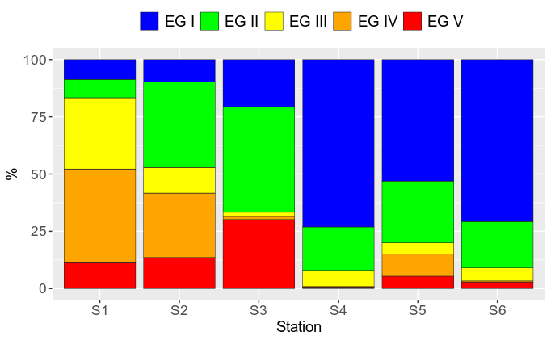

Save the plot. I think the colours are exceptionally ugly, but I suppose there’s nothing to be done, stupid standards.

```r
ggsave(filename = here(figures.dir, "eg_ambi_sand.png"),
       plot.ambi.eg.sand,
       dpi = 300, width = 15, height = 15, units = "cm")
```

###### **BENTIX**

On to the BENTIX calculations.

|  | N | GS(%) | GT(%) | NA | BENTIX |
| --- | --- | --- | --- | --- | --- |
| Kraimorie_1 | 384 | 15.36 | 83.59 | 1.04 | 2.594 |
| Kraimorie_2 | 477 | 6.92 | 93.08 | 0.00 | 2.277 |
| Kraimorie_3 | 380 | 11.05 | 88.95 | 0.00 | 2.442 |
| Kraimorie_4 | 309 | 6.80 | 93.20 | 0.00 | 2.272 |
| Kraimorie_5 | 296 | 6.42 | 93.58 | 0.00 | 2.257 |
| Kraimorie_6 | 234 | 12.39 | 87.61 | 0.00 | 2.496 |
| Kraimorie_7 | 380 | 5.26 | 94.47 | 0.26 | 2.205 |
| Kraimorie_8 | 425 | 12.94 | 86.12 | 0.94 | 2.499 |
| Kraimorie_9 | 464 | 11.42 | 87.50 | 1.08 | 2.435 |
| Chukalya_1 | 214 | 13.55 | 85.51 | 0.93 | 2.523 |

[output cut: 44 more lines]

Put all indices in one single tibble (to avoid excessive workspace clutter).

| station | year | month | biotope | S | H1 | AMBI | BENTIX | M-AMBI | M-AMBIn | H.EQR | AMBI.EQR | BENTIX.EQR | M-AMBIn.EQR |
| --- | --- | --- | --- | --- | --- | --- | --- | --- | --- | --- | --- | --- | --- |
| Kraimorie | 2013 | 6 | ILitMMelin | 31 | 3.641 | 3.292 | 2.594 | 0.719 | 0.860 | 0.910 | 0.451 | 0.432 | 0.989 |
| Kraimorie | 2013 | 6 | ILitMMelin | 29 | 3.197 | 3.682 | 2.277 | 0.719 | 0.771 | 0.799 | 0.386 | 0.380 | 0.886 |
| Kraimorie | 2013 | 6 | ILitMMelin | 33 | 3.705 | 3.521 | 2.442 | 0.719 | 0.875 | 0.926 | 0.413 | 0.407 | 1.006 |
| Kraimorie | 2013 | 9 | ILitMMelin | 31 | 3.416 | 3.621 | 2.272 | 0.659 | 0.818 | 0.854 | 0.396 | 0.379 | 0.940 |
| Kraimorie | 2013 | 9 | ILitMMelin | 28 | 2.993 | 3.623 | 2.257 | 0.659 | 0.744 | 0.748 | 0.396 | 0.376 | 0.855 |
| Kraimorie | 2013 | 9 | ILitMMelin | 28 | 3.516 | 3.449 | 2.496 | 0.659 | 0.805 | 0.879 | 0.425 | 0.416 | 0.925 |
| Kraimorie | 2014 | 7 | ILitMMelin | 25 | 3.063 | 3.742 | 2.205 | 0.731 | 0.710 | 0.766 | 0.376 | 0.368 | 0.816 |
| Kraimorie | 2014 | 7 | ILitMMelin | 37 | 3.518 | 3.633 | 2.499 | 0.731 | 0.894 | 0.880 | 0.394 | 0.417 | 1.028 |
| Kraimorie | 2014 | 7 | ILitMMelin | 32 | 3.436 | 3.582 | 2.435 | 0.731 | 0.834 | 0.859 | 0.403 | 0.406 | 0.959 |
| Chukalya | 2013 | 6 | ILitMMelin | 20 | 3.087 | 2.761 | 2.523 | 0.860 | 0.714 | 0.772 | 0.540 | 0.421 | 0.821 |

[output cut: 44 more lines]

Calculate the EQRs for AMBI, BENTIX and H’.

| station | year | month | biotope | S | H1 | AMBI | BENTIX | M-AMBI | M-AMBIn | H.EQR | AMBI.EQR | BENTIX.EQR | M-AMBIn.EQR |
| --- | --- | --- | --- | --- | --- | --- | --- | --- | --- | --- | --- | --- | --- |
| Kraimorie | 2013 | 6 | ILitMMelin | 31 | 3.641 | 3.292 | 2.594 | 0.719 | 0.860 | 0.910 | 0.451 | 0.432 | 0.989 |
| Kraimorie | 2013 | 6 | ILitMMelin | 29 | 3.197 | 3.682 | 2.277 | 0.719 | 0.771 | 0.799 | 0.386 | 0.380 | 0.886 |
| Kraimorie | 2013 | 6 | ILitMMelin | 33 | 3.705 | 3.521 | 2.442 | 0.719 | 0.875 | 0.926 | 0.413 | 0.407 | 1.006 |
| Kraimorie | 2013 | 9 | ILitMMelin | 31 | 3.416 | 3.621 | 2.272 | 0.659 | 0.818 | 0.854 | 0.396 | 0.379 | 0.940 |
| Kraimorie | 2013 | 9 | ILitMMelin | 28 | 2.993 | 3.623 | 2.257 | 0.659 | 0.744 | 0.748 | 0.396 | 0.376 | 0.855 |
| Kraimorie | 2013 | 9 | ILitMMelin | 28 | 3.516 | 3.449 | 2.496 | 0.659 | 0.805 | 0.879 | 0.425 | 0.416 | 0.925 |
| Kraimorie | 2014 | 7 | ILitMMelin | 25 | 3.063 | 3.742 | 2.205 | 0.731 | 0.710 | 0.766 | 0.376 | 0.368 | 0.816 |
| Kraimorie | 2014 | 7 | ILitMMelin | 37 | 3.518 | 3.633 | 2.499 | 0.731 | 0.894 | 0.880 | 0.394 | 0.417 | 1.028 |
| Kraimorie | 2014 | 7 | ILitMMelin | 32 | 3.436 | 3.582 | 2.435 | 0.731 | 0.834 | 0.859 | 0.403 | 0.406 | 0.959 |
| Chukalya | 2013 | 6 | ILitMMelin | 20 | 3.087 | 2.761 | 2.523 | 0.860 | 0.714 | 0.772 | 0.540 | 0.421 | 0.821 |

[output cut: 44 more lines]

###### **M-AMBIn (simplified M-AMBI)**

M-AMBIn is a simplification of M-AMBI which is only a simple average of min-max normalized values. Each biotope is supposed to have specific reference values for all component indices; however, not all biotopes in the current dataset have them.  
For the sake of completeness, for ILitMMelin, I’ll use the reference values for ILitFSCham (there is some *C.gallina* at the sandy mud stations), and for ILitMSVar - the reference values for ILitCSUpog (they are closest in terms of species composition).

| station | rep | M-AMBI*(n) |
| --- | --- | --- |
| Kraimorie | 1 | 0.860 |
| Kraimorie | 2 | 0.771 |
| Kraimorie | 3 | 0.875 |
| Kraimorie | 4 | 0.818 |
| Kraimorie | 5 | 0.744 |
| Kraimorie | 6 | 0.805 |
| Kraimorie | 7 | 0.710 |
| Kraimorie | 8 | 0.894 |
| Kraimorie | 9 | 0.834 |
| Chukalya | 1 | 0.714 |

[output cut: 44 more lines]

Calculate M-AMBI*n EQRs according to biotope (same concessions as above).

| station | year | month | biotope | S | H1 | AMBI | BENTIX | M-AMBI | M-AMBIn | H.EQR | AMBI.EQR | BENTIX.EQR | M-AMBIn.EQR |
| --- | --- | --- | --- | --- | --- | --- | --- | --- | --- | --- | --- | --- | --- |
| Kraimorie | 2013 | 6 | ILitMMelin | 31 | 3.641 | 3.292 | 2.594 | 0.719 | 0.860 | 0.910 | 0.451 | 0.432 | 0.989 |
| Kraimorie | 2013 | 6 | ILitMMelin | 29 | 3.197 | 3.682 | 2.277 | 0.719 | 0.771 | 0.799 | 0.386 | 0.380 | 0.886 |
| Kraimorie | 2013 | 6 | ILitMMelin | 33 | 3.705 | 3.521 | 2.442 | 0.719 | 0.875 | 0.926 | 0.413 | 0.407 | 1.006 |
| Kraimorie | 2013 | 9 | ILitMMelin | 31 | 3.416 | 3.621 | 2.272 | 0.659 | 0.818 | 0.854 | 0.396 | 0.379 | 0.940 |
| Kraimorie | 2013 | 9 | ILitMMelin | 28 | 2.993 | 3.623 | 2.257 | 0.659 | 0.744 | 0.748 | 0.396 | 0.376 | 0.855 |
| Kraimorie | 2013 | 9 | ILitMMelin | 28 | 3.516 | 3.449 | 2.496 | 0.659 | 0.805 | 0.879 | 0.425 | 0.416 | 0.925 |
| Kraimorie | 2014 | 7 | ILitMMelin | 25 | 3.063 | 3.742 | 2.205 | 0.731 | 0.710 | 0.766 | 0.376 | 0.368 | 0.816 |
| Kraimorie | 2014 | 7 | ILitMMelin | 37 | 3.518 | 3.633 | 2.499 | 0.731 | 0.894 | 0.880 | 0.394 | 0.417 | 1.028 |
| Kraimorie | 2014 | 7 | ILitMMelin | 32 | 3.436 | 3.582 | 2.435 | 0.731 | 0.834 | 0.859 | 0.403 | 0.406 | 0.959 |
| Chukalya | 2013 | 6 | ILitMMelin | 20 | 3.087 | 2.761 | 2.523 | 0.860 | 0.714 | 0.772 | 0.540 | 0.421 | 0.821 |

[output cut: 44 more lines]

Save this, finally.

```r
write_csv(indices.all.sand,
          here(save.dir, "indices_all_sand.csv"))
```

##### Exploratory analysis

Now we’ll do some exploratory analyses & summaries on the indices.  
I’ll work mostly with the EQRs from now on (directly comparable).

| station | M-AMBI_mean | H.EQR_mean | AMBI.EQR_mean | BENTIX.EQR_mean | M-AMBIn.EQR_mean | M-AMBI_sd | H.EQR_sd | AMBI.EQR_sd | BENTIX.EQR_sd | M-AMBIn.EQR_sd |
| --- | --- | --- | --- | --- | --- | --- | --- | --- | --- | --- |
| Kraimorie | 0.7030000 | 0.8467778 | 0.4044444 | 0.3978889 | 0.9337778 | 0.03340659 | 0.06243152 | 0.02254502 | 0.02251358 | 0.07093620 |
| Chukalya | 0.8546667 | 0.9296667 | 0.5038889 | 0.4084444 | 0.9955556 | 0.07631514 | 0.07821445 | 0.02785877 | 0.02094702 | 0.09702849 |
| Akin | 0.6006667 | 0.6512222 | 0.5637778 | 0.4808889 | 0.8397778 | 0.09748974 | 0.10557080 | 0.13949532 | 0.04524225 | 0.12878837 |
| Sozopol | 0.5610000 | 0.3823333 | 0.9086667 | 0.9264444 | 0.7841111 | 0.07234812 | 0.12226304 | 0.06191325 | 0.03748703 | 0.06300088 |
| Agalina | 1.1070000 | 0.9907778 | 0.7816667 | 0.5281111 | 1.2581111 | 0.01281601 | 0.09367601 | 0.02161018 | 0.04123847 | 0.02192855 |
| Paraskeva | 0.8650000 | 0.7406667 | 0.8886667 | 0.8662222 | 1.0483333 | 0.06991245 | 0.13371144 | 0.05256900 | 0.04551862 | 0.09304972 |

| biotope | M-AMBI_mean | H.EQR_mean | AMBI.EQR_mean | BENTIX.EQR_mean | M-AMBIn.EQR_mean | M-AMBI_sd | H.EQR_sd | AMBI.EQR_sd | BENTIX.EQR_sd | M-AMBIn.EQR_sd |
| --- | --- | --- | --- | --- | --- | --- | --- | --- | --- | --- |
| ILitMMelin | 0.7788333 | 0.8882222 | 0.4541667 | 0.4031667 | 0.9646667 | 0.09672049 | 0.08081901 | 0.05676396 | 0.02178302 | 0.08836622 |
| ILitCSUpog | 0.6006667 | 0.6512222 | 0.5637778 | 0.4808889 | 0.8397778 | 0.09748974 | 0.10557080 | 0.13949532 | 0.04524225 | 0.12878837 |
| ILitFSCham | 0.7130000 | 0.5615000 | 0.8986667 | 0.8963333 | 0.9162222 | 0.17095717 | 0.22234426 | 0.05665894 | 0.05095442 | 0.15627636 |
| ILitMSVar | 1.1070000 | 0.9907778 | 0.7816667 | 0.5281111 | 1.2581111 | 0.01281601 | 0.09367601 | 0.02161018 | 0.04123847 | 0.02192855 |

###### **Differences in assessment between stations and biotopes**

Next, we want to see if the indices differ between **stations** - as a proxy to the anthropogenic pressure gradient, going from 1 (most impacted) to 6 (least impacted), and between **biotopes** - to see if index performance is influenced also by the structure & characteristics of the macrobenthic community.  
Unfortunately, the distribution of the values is not normal - not really surprising for ecological data, but causes problems for parametric statistical tests such as ANOVA. This can easily be seen from the q-q plots:

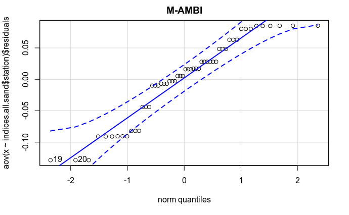

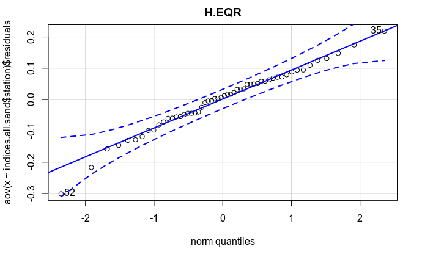

```
'rlm' failed to converge in 20 steps
```

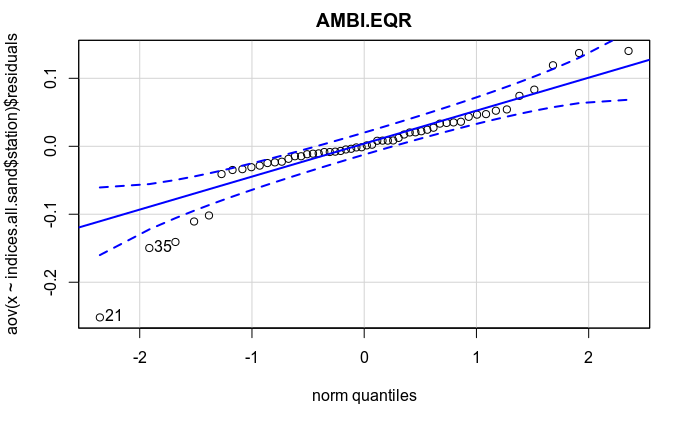

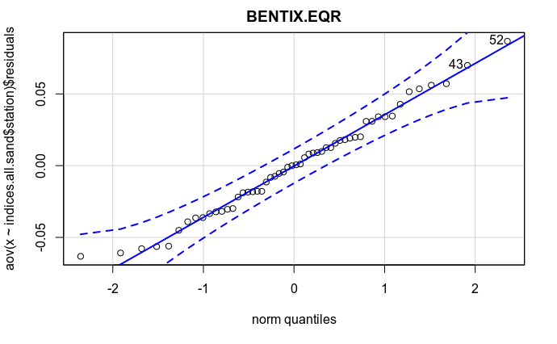

```
     M-AMBI H.EQR AMBI.EQR BENTIX.EQR M-AMBIn.EQR
[1,]     19    52       21         52          21
[2,]     20    35       35         43          10
```

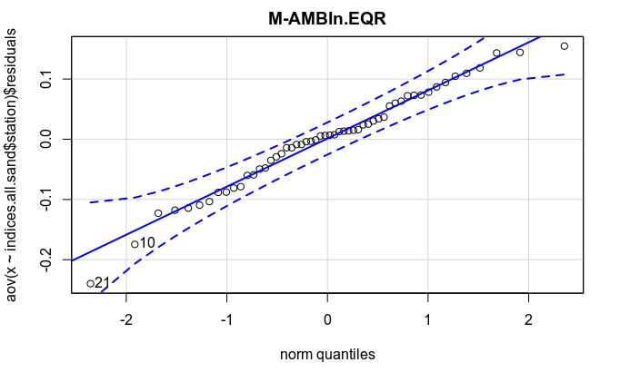

```r
mapply(function(x, y) car::qqPlot(aov(x ~ indices.all.sand$station)$residuals, line = "robust", main = y),
       x = indices.all.sand %>% select(`M-AMBI`, ends_with("EQR")),
       y = names(indices.all.sand %>% select(`M-AMBI`, ends_with("EQR")))
       )
```

The worst offender is, by far, AMBI (most extreme outlier - #21, Akin). In general, Akin samples are responsible for this - they have extremely high variance, with Sozopol, Paraskeva & sometimes Chukalya also contributing to the distortions.

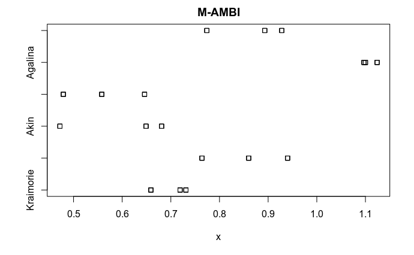

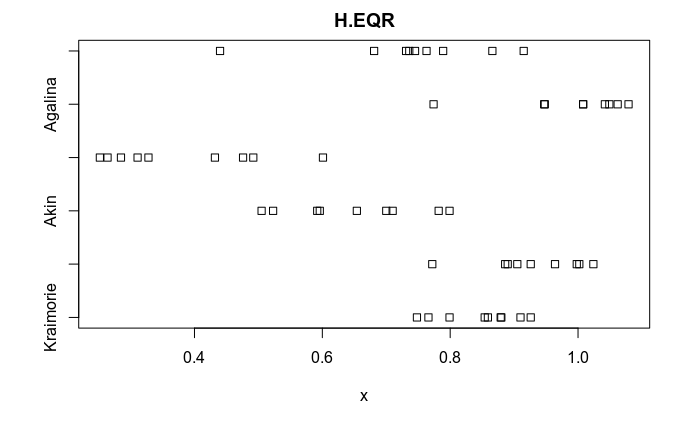

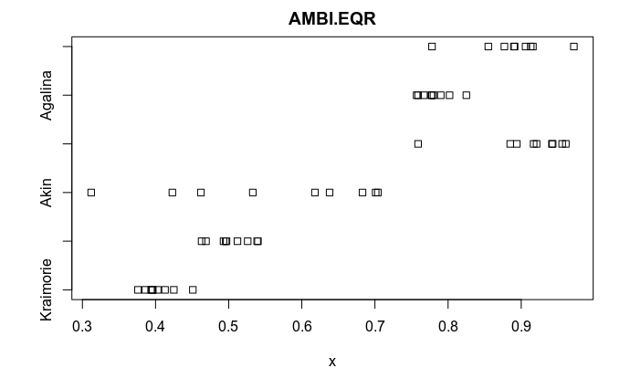

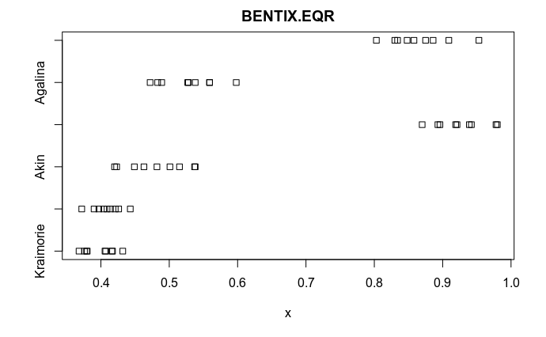

```
$`M-AMBI`
NULL

$H.EQR
NULL

$AMBI.EQR
NULL

$BENTIX.EQR
NULL

$`M-AMBIn.EQR`
NULL
```

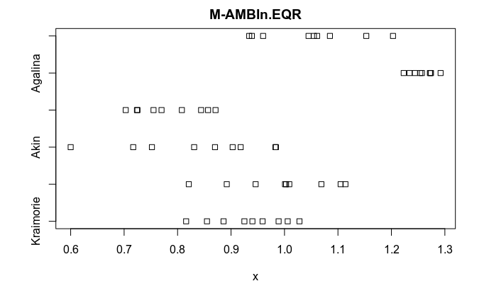

```r
mapply(function(x, y) stripchart(x ~ indices.all.sand$station, main = y),
       x = indices.all.sand %>% select(`M-AMBI`, ends_with("EQR")),
       y = names(indices.all.sand %>% select(`M-AMBI`, ends_with("EQR")))
       )
```

These outliers cannot be removed from the dataset in good conscience - they are not the result of an error of measurement, manipulation or other. Rather, they are probably a reflection of the natural variability and mosaic distribution of the zoobenthic communities. From the MDS plot & cluster analysis it’s clear to which community/biotope the samples belong (there is little overlap).  
Therefore, we have to look for **alternatives to normal ANOVA** that can deal with outliers. One such method is **robust regression** (source of original code & ideas: https://stats.idre.ucla.edu/r/dae/robust-regression/). The idea of robust regression is to weigh the observations differently based on how well behaved these observations are. Roughly speaking, it is a form of weighted and reweighted least squares regression.  
Robust regression is done by iteratively re-weighted least squares (IRLS). There are several weighting functions that can be used for IRLS; here, we are going to use Huber weights. Side note: in OLS regression, all cases have a weight of 1. Hence, the more cases in the robust regression that have a weight close to one, the closer the results of the OLS and robust regressions. If the results are very different, we will most likely want to use the results from the robust regression. Large differences suggest that the model parameters are being highly influenced by outliers. Huber weights can have difficulties with severe outliers, and bisquare weights can have difficulties converging or may yield multiple solutions.  
Robust regression does not address issues of heterogeneity of variance. This problem can be addressed by using functions in the sandwich package after the lm function -> estimate valid standard errors for our coefficients in linear regression, without requiring (the usual assumption) that the residual errors have constant variance.  
Here, after much digging, reading and wondering about all that, I settled on this procedure: **multiple comparison of means using heteroscedastic consistent covariance estimation** (Herberich et al, 2010. A Robust Procedure for Comparing Multiple Means under Heteroscedasticity in Unbalanced Designs. PLoS ONE 5(3): e9788. https://doi.org/10.1371/journal.pone.0009788).

First - robust regression with station as factor.

```r
lapply(ind.rr.st.sand, summary)
```

```
$`M-AMBI`

Call: rlm(formula = x ~ station, data = indices.all.sand)
Residuals:
      Min        1Q    Median        3Q       Max
-0.157107 -0.044000  0.008009  0.028000  0.087987

Coefficients:
                 Value   Std. Error t value
(Intercept)       0.7030  0.0266    26.4124
stationChukalya   0.1570  0.0376     4.1705
stationAkin      -0.0739  0.0376    -1.9631
stationSozopol   -0.1450  0.0376    -3.8518
stationAgalina    0.4040  0.0376    10.7329
stationParaskeva  0.1716  0.0376     4.5590

Residual standard error: 0.05337 on 48 degrees of freedom

$H.EQR

Call: rlm(formula = x ~ station, data = indices.all.sand)
Residuals:
      Min        1Q    Median        3Q       Max
-0.318714 -0.056027  0.004504  0.062299  0.232199

Coefficients:
                 Value    Std. Error t value
(Intercept)        0.8468   0.0337    25.1297
stationChukalya    0.0880   0.0477     1.8466
stationAkin       -0.1964   0.0477    -4.1209
stationSozopol    -0.4780   0.0477   -10.0302
stationAgalina     0.1565   0.0477     3.2841
stationParaskeva  -0.0881   0.0477    -1.8480

Residual standard error: 0.08683 on 48 degrees of freedom

$AMBI.EQR

Call: rlm(formula = x ~ station, data = indices.all.sand)
Residuals:
```

[output cut: 34 more lines]

```
Call: rlm(formula = x ~ station, data = indices.all.sand)
Residuals:
     Min       1Q   Median       3Q      Max
-0.25479 -0.05521  0.00375  0.05288  0.16006

Coefficients:
                 Value   Std. Error t value
(Intercept)       0.9346  0.0283    33.0490
stationChukalya   0.0689  0.0400     1.7223
stationAkin      -0.0798  0.0400    -1.9945
stationSozopol   -0.1504  0.0400    -3.7620
stationAgalina    0.3236  0.0400     8.0907
stationParaskeva  0.1084  0.0400     2.7103

Residual standard error: 0.08293 on 48 degrees of freedom
```

Now we’ll do the appropriate post-hoc tests to see where the largest differences are.

```r
lapply(ind.glht.st.sand, summary)
```

```
$`M-AMBI`

     Simultaneous Tests for General Linear Hypotheses

Multiple Comparisons of Means: Tukey Contrasts


Fit: rlm(formula = x ~ station, data = indices.all.sand)

Linear Hypotheses:
                           Estimate Std. Error z value Pr(>|z|)
Chukalya - Kraimorie == 0   0.15698    0.06646   2.362  0.13670
Akin - Kraimorie == 0      -0.07389    0.03118  -2.370  0.13413
Sozopol - Kraimorie == 0   -0.14499    0.06659  -2.177  0.20486
Agalina - Kraimorie == 0    0.40400    0.01265  31.936  < 0.001 ***
Paraskeva - Kraimorie == 0  0.17161    0.03164   5.424  < 0.001 ***
Akin - Chukalya == 0       -0.23087    0.07148  -3.230  0.01147 *
Sozopol - Chukalya == 0    -0.30197    0.09258  -3.262  0.01058 *
Agalina - Chukalya == 0     0.24702    0.06556   3.768  0.00171 **
Paraskeva - Chukalya == 0   0.01463    0.07169   0.204  0.99993
Sozopol - Akin == 0        -0.07109    0.07160  -0.993  0.89911
Agalina - Akin == 0         0.47789    0.02921  16.361  < 0.001 ***
Paraskeva - Akin == 0       0.24550    0.04116   5.965  < 0.001 ***
Agalina - Sozopol == 0      0.54899    0.06569   8.358  < 0.001 ***
Paraskeva - Sozopol == 0    0.31659    0.07180   4.409  < 0.001 ***
Paraskeva - Agalina == 0   -0.23239    0.02970  -7.826  < 0.001 ***
---
Signif. codes:  0 ‘***’ 0.001 ‘**’ 0.01 ‘*’ 0.05 ‘.’ 0.1 ‘ ’ 1
(Adjusted p values reported -- single-step method)


$H.EQR

     Simultaneous Tests for General Linear Hypotheses

Multiple Comparisons of Means: Tukey Contrasts


Fit: rlm(formula = x ~ station, data = indices.all.sand)

```

[output cut: 98 more lines]

```
Agalina - Kraimorie == 0    0.32355    0.02867  11.285   <0.001 ***
Paraskeva - Kraimorie == 0  0.10839    0.04322   2.508   0.1070
Akin - Chukalya == 0       -0.14864    0.06654  -2.234   0.1986
Sozopol - Chukalya == 0    -0.21932    0.03966  -5.529   <0.001 ***
Agalina - Chukalya == 0     0.25468    0.03372   7.552   <0.001 ***
Paraskeva - Chukalya == 0   0.03951    0.04672   0.846   0.9517
Sozopol - Akin == 0        -0.07068    0.06202  -1.140   0.8459
Agalina - Akin == 0         0.40332    0.05840   6.906   <0.001 ***
Paraskeva - Akin == 0       0.18815    0.06676   2.818   0.0473 *
Agalina - Sozopol == 0      0.47400    0.02358  20.098   <0.001 ***
Paraskeva - Sozopol == 0    0.25883    0.04002   6.467   <0.001 ***
Paraskeva - Agalina == 0   -0.21517    0.03414  -6.302   <0.001 ***
---
Signif. codes:  0 ‘***’ 0.001 ‘**’ 0.01 ‘*’ 0.05 ‘.’ 0.1 ‘ ’ 1
(Adjusted p values reported -- single-step method)
```

Now - robust regression with biotopes as factor.  
(MASS::rlm doesn’t like multiple regression with both stations and biotopes, because there are multiple duplicate combinations of the two factors, which causes multicollnearity & hence breaks the analysis).

```r
lapply(ind.rr.biotope.sand, summary)
```

```
$`M-AMBI`

Call: rlm(formula = x ~ biotope, data = indices.all.sand)
Residuals:
     Min       1Q   Median       3Q      Max
-0.23102 -0.06402 -0.00850  0.08033  0.21798

Coefficients:
                  Value   Std. Error t value
(Intercept)        0.7754  0.0333    23.3077
biotopeILitCSUpog -0.1747  0.0576    -3.0323
biotopeILitFSCham -0.0654  0.0470    -1.3894
biotopeILitMSVar   0.3316  0.0576     5.7551

Residual standard error: 0.107 on 50 degrees of freedom

$H.EQR

Call: rlm(formula = x ~ biotope, data = indices.all.sand)
Residuals:
     Min       1Q   Median       3Q      Max
-0.32013 -0.09440  0.00800  0.08211  0.34287

Coefficients:
                  Value   Std. Error t value
(Intercept)        0.8882  0.0351    25.3208
biotopeILitCSUpog -0.2370  0.0608    -3.9007
biotopeILitFSCham -0.3161  0.0496    -6.3718
biotopeILitMSVar   0.1066  0.0608     1.7538

Residual standard error: 0.1374 on 50 degrees of freedom

$AMBI.EQR

Call: rlm(formula = x ~ biotope, data = indices.all.sand)
Residuals:
      Min        1Q    Median        3Q       Max
-0.284316 -0.037780 -0.000162  0.041068  0.107684

Coefficients:
```

[output cut: 24 more lines]

```
$`M-AMBIn.EQR`

Call: rlm(formula = x ~ biotope, data = indices.all.sand)
Residuals:
      Min        1Q    Median        3Q       Max
-0.254800 -0.069972  0.006389  0.053062  0.297682

Coefficients:
                  Value   Std. Error t value
(Intercept)        0.9649  0.0332    29.0887
biotopeILitCSUpog -0.1101  0.0575    -1.9157
biotopeILitFSCham -0.0595  0.0469    -1.2693
biotopeILitMSVar   0.2933  0.0575     5.1044

Residual standard error: 0.09227 on 50 degrees of freedom
```

… and the post-hoc tests:

```r
lapply(ind.glht.biotope.sand, summary)
```

```
$`M-AMBI`

     Simultaneous Tests for General Linear Hypotheses

Multiple Comparisons of Means: Tukey Contrasts


Fit: rlm(formula = x ~ biotope, data = indices.all.sand)

Linear Hypotheses:
                             Estimate Std. Error z value Pr(>|z|)
ILitCSUpog - ILitMMelin == 0 -0.17472    0.04340  -4.026   <0.001 ***
ILitFSCham - ILitMMelin == 0 -0.06537    0.09557  -0.684    0.889
ILitMSVar - ILitMMelin == 0   0.33161    0.02675  12.395   <0.001 ***
ILitFSCham - ILitCSUpog == 0  0.10935    0.09812   1.115    0.648
ILitMSVar - ILitCSUpog == 0   0.50633    0.03476  14.565   <0.001 ***
ILitMSVar - ILitFSCham == 0   0.39698    0.09198   4.316   <0.001 ***
---
Signif. codes:  0 ‘***’ 0.001 ‘**’ 0.01 ‘*’ 0.05 ‘.’ 0.1 ‘ ’ 1
(Adjusted p values reported -- single-step method)


$H.EQR

     Simultaneous Tests for General Linear Hypotheses

Multiple Comparisons of Means: Tukey Contrasts


Fit: rlm(formula = x ~ biotope, data = indices.all.sand)

Linear Hypotheses:
                             Estimate Std. Error z value Pr(>|z|)
ILitCSUpog - ILitMMelin == 0 -0.23700    0.04216  -5.622   <0.001 ***
ILitFSCham - ILitMMelin == 0 -0.31610    0.08145  -3.881   <0.001 ***
ILitMSVar - ILitMMelin == 0   0.10656    0.03827   2.784   0.0246 *
ILitFSCham - ILitCSUpog == 0 -0.07910    0.08743  -0.905   0.7897
ILitMSVar - ILitCSUpog == 0   0.34356    0.04973   6.908   <0.001 ***
ILitMSVar - ILitFSCham == 0   0.42265    0.08562   4.936   <0.001 ***
---
```

[output cut: 53 more lines]

```


Fit: rlm(formula = x ~ biotope, data = indices.all.sand)

Linear Hypotheses:
                             Estimate Std. Error z value Pr(>|z|)
ILitCSUpog - ILitMMelin == 0 -0.11006    0.06770  -1.626    0.333
ILitFSCham - ILitMMelin == 0 -0.05954    0.07035  -0.846    0.814
ILitMSVar - ILitMMelin == 0   0.29325    0.02614  11.218   <0.001 ***
ILitFSCham - ILitCSUpog == 0  0.05052    0.09103   0.555    0.938
ILitMSVar - ILitCSUpog == 0   0.40331    0.06341   6.361   <0.001 ***
ILitMSVar - ILitFSCham == 0   0.35279    0.06623   5.327   <0.001 ***
---
Signif. codes:  0 ‘***’ 0.001 ‘**’ 0.01 ‘*’ 0.05 ‘.’ 0.1 ‘ ’ 1
(Adjusted p values reported -- single-step method)
```

Ok, now we know there are **significant differences** in index assessments between stations as well as between biotopes (+ between which pairs). Let’s plot them, using the summary tables we did before (mean + sd):

| station | index | mean | sd | label |
| --- | --- | --- | --- | --- |
| Kraimorie | AMBI | 0.4044444 | 0.02254502 | a |
| Kraimorie | BENTIX | 0.3978889 | 0.02251358 | a |
| Kraimorie | H' | 0.8467778 | 0.06243152 | cd |
| Kraimorie | M-AMBI | 0.7030000 | 0.03340659 | ab |
| Kraimorie | M-AMBIn | 0.9337778 | 0.07093620 | bc |
| Chukalya | AMBI | 0.5038889 | 0.02785877 | b |
| Chukalya | BENTIX | 0.4084444 | 0.02094702 | a |
| Chukalya | H' | 0.9296667 | 0.07821445 | de |
| Chukalya | M-AMBI | 0.8546667 | 0.07631514 | bc |
| Chukalya | M-AMBIn | 0.9955556 | 0.09702849 | bc |

[output cut: 20 more lines]

We need to get and add the significance labels (will make life immensely easier if they are in the same tibble).

| station | index | mean | sd | label |
| --- | --- | --- | --- | --- |
| Kraimorie | AMBI | 0.4044444 | 0.02254502 | a |
| Kraimorie | BENTIX | 0.3978889 | 0.02251358 | a |
| Kraimorie | H' | 0.8467778 | 0.06243152 | cd |
| Kraimorie | M-AMBI | 0.7030000 | 0.03340659 | ab |
| Kraimorie | M-AMBIn | 0.9337778 | 0.07093620 | bc |
| Chukalya | AMBI | 0.5038889 | 0.02785877 | b |
| Chukalya | BENTIX | 0.4084444 | 0.02094702 | a |
| Chukalya | H' | 0.9296667 | 0.07821445 | de |
| Chukalya | M-AMBI | 0.8546667 | 0.07631514 | bc |
| Chukalya | M-AMBIn | 0.9955556 | 0.09702849 | bc |

[output cut: 20 more lines]

Make another tibble to hold the ecological class limits for the summary plots (by stations & biotopes). The idea is to make them appear as horizontal lines over the plot.

| H' | AMBI | M-AMBI | BENTIX | M-AMBIn |
| --- | --- | --- | --- | --- |
| 0.89 | 0.83 | 0.85 | 0.75 | 0.87 |
| 0.69 | 0.53 | 0.55 | 0.58 | 0.66 |
| 0.49 | 0.39 | 0.39 | 0.42 | 0.44 |
| 0.29 | 0.21 | 0.20 | 0.00 | 0.22 |

Plot the comparison of the indices by station.

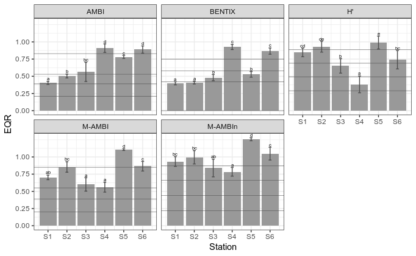

```r
plot.ind.st.summary.sand <- ggplot(ind.st.summary.sand.long,
                                   aes(x = as.numeric(station), y = mean)) +
  geom_bar(position = position_dodge(), stat = "identity", fill = "grey60") +
  ## error bars = sd
  geom_errorbar(aes(ymin = mean - sd, ymax = mean + sd),
                width = 0.15, colour = "grey30", position = position_dodge(0.9)) +
  ## labels - significant difference pairs (above error bars)
  geom_text(aes(x = as.numeric(station), y = mean + sd, label = label), vjust = -0.3, size = 2) +
  labs(x = "Station", y = "EQR") +
  facet_wrap(~index) +
  scale_y_continuous(breaks = seq(0, 1, 0.25)) +
  scale_x_continuous(breaks = 1:6, labels = paste0("S", unique(as.numeric(ind.st.summary.sand.long$station))))

## add the limits of the ecological classes for each index
## NB names of indices (facets) have to match in order for the lines to go where they should (otherwise they'll go in separate, additional facets)!
(plot.ind.st.summary.sand <- plot.ind.st.summary.sand +
    geom_hline(data = ind.limits.long, aes(yintercept = limits), lwd = 0.2, colour = "grey30")
)
```

I really don’t like the lines (nor the fact that I have to add labels manually later, outside of R), but I suppose it can’t be helped, at least now.

Save the station summary plot.

```r
ggsave(here(figures.dir, "ind_station_summary_sand.png"),
       plot.ind.st.summary.sand,
       dpi = 300, width = 17, height = 15, units = "cm")
```

Make another summary plot for the biotopes.

```r
ind.biotope.summary.sand.long <- ind.biotope.summary %>%
    gather(key = ind, value = ind_value, -biotope) %>%
    ## separate the index column into 2: index and variable (mean or sd)
    separate(ind, into = c("index", "var"), sep = "_") %>%
    spread(var, ind_value)

## get rid of the "EQR" at the end of the index names
ind.biotope.summary.sand.long <- ind.biotope.summary.sand.long %>%
  mutate(index = gsub(index, pattern = ".EQR", replacement = ""))

## replace H with H' and convert index to factor (to have them in the desired order)
(ind.biotope.summary.sand.long <- ind.biotope.summary.sand.long %>%
    mutate(index = gsub(index, pattern = "H", replacement = "H'")) %>%
    mutate(index = factor(index, levels = c("AMBI", "BENTIX", "H'", "M-AMBI", "M-AMBIn"))) %>%
    mutate(biotope = factor(biotope, levels = levels(indices.all.sand$biotope)))
)
```

| biotope | index | mean | sd |
| --- | --- | --- | --- |
| ILitCSUpog | AMBI | 0.5637778 | 0.13949532 |
| ILitCSUpog | BENTIX | 0.4808889 | 0.04524225 |
| ILitCSUpog | H' | 0.6512222 | 0.10557080 |
| ILitCSUpog | M-AMBI | 0.6006667 | 0.09748974 |
| ILitCSUpog | M-AMBIn | 0.8397778 | 0.12878837 |
| ILitFSCham | AMBI | 0.8986667 | 0.05665894 |
| ILitFSCham | BENTIX | 0.8963333 | 0.05095442 |
| ILitFSCham | H' | 0.5615000 | 0.22234426 |
| ILitFSCham | M-AMBI | 0.7130000 | 0.17095717 |
| ILitFSCham | M-AMBIn | 0.9162222 | 0.15627636 |

[output cut: 10 more lines]

Get the significance labels.

```r
## extract the significance letter labels that we generated before.
ind.biotope.labels.sand <- plyr::ldply(mcp.biotope.labels.sand, function(x) x[[10]][[1]])

## fix index names
ind.biotope.labels.sand$.id <- recode(ind.biotope.labels.sand$.id,
                                      "H.EQR" = "H'", "AMBI.EQR" = "AMBI", "M-AMBI" = "M-AMBI", "BENTIX.EQR" = "BENTIX", "M-AMBIn.EQR" = "M-AMBIn")

ind.biotope.labels.sand$.id <- factor(ind.biotope.labels.sand$.id, levels = c("AMBI", "BENTIX", "H'", "M-AMBI", "M-AMBIn"))

ind.biotope.labels.sand
```

| .id | ILitMMelin | ILitCSUpog | ILitFSCham | ILitMSVar |
| --- | --- | --- | --- | --- |
| M-AMBI | b | a | ab | c |
| H' | b | a | a | c |
| AMBI | a | ab | c | b |
| BENTIX | a | b | c | b |
| M-AMBIn | a | a | a | b |

```r
## convert to long & rename the index column
ind.biotope.labels.sand.long <- ind.biotope.labels.sand %>%
    gather(key = biotope, value = label, -.id) %>%
    rename(index = .id) %>%
    mutate(biotope = factor(biotope, levels = levels(indices.all.sand$biotope)))

## add to the dataset for plotting
(ind.biotope.summary.sand.long <- left_join(ind.biotope.summary.sand.long,
                                            ind.biotope.labels.sand.long,
                                            by = c("biotope", "index"))
)
```

| biotope | index | mean | sd | label |
| --- | --- | --- | --- | --- |
| ILitCSUpog | AMBI | 0.5637778 | 0.13949532 | ab |
| ILitCSUpog | BENTIX | 0.4808889 | 0.04524225 | b |
| ILitCSUpog | H' | 0.6512222 | 0.10557080 | a |
| ILitCSUpog | M-AMBI | 0.6006667 | 0.09748974 | a |
| ILitCSUpog | M-AMBIn | 0.8397778 | 0.12878837 | a |
| ILitFSCham | AMBI | 0.8986667 | 0.05665894 | c |
| ILitFSCham | BENTIX | 0.8963333 | 0.05095442 | c |
| ILitFSCham | H' | 0.5615000 | 0.22234426 | a |
| ILitFSCham | M-AMBI | 0.7130000 | 0.17095717 | ab |
| ILitFSCham | M-AMBIn | 0.9162222 | 0.15627636 | a |

[output cut: 10 more lines]

Plot, keeping the x axis numeric, because the biotope codes take up too much space otherwise, and making them readable is a hassle. For the record, they are in order of the factor levels: 1 - ILitMMelin, 2 - ILitCSUpog, 3 - ILitFSCham, 4 - ILitMSVar.

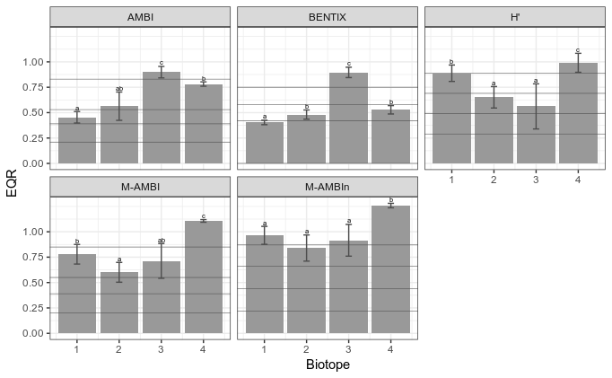

```r
plot.ind.biotope.summary.sand <- ggplot(ind.biotope.summary.sand.long,
                                        aes(x = as.numeric(biotope), y = mean)) +
  geom_bar(position = position_dodge(), stat = "identity", fill = "grey60") +
  ## error bars = sd
  geom_errorbar(aes(ymin = mean - sd, ymax = mean + sd),
                width = 0.15, colour = "grey30", position = position_dodge(0.9)) +
  ## labels - significant differences between pairs
  geom_text(aes(x = as.numeric(biotope), y = mean + sd, label = label), vjust = -0.3, size = 2) +
  labs(x = "Biotope", y = "EQR") +
  facet_wrap(~index) +
  scale_y_continuous(breaks = seq(0, 1, 0.25)) +
  scale_x_continuous(breaks = 1:4)

## add the limits of the ecological classes for each index
(plot.ind.biotope.summary.sand <- plot.ind.biotope.summary.sand +
    geom_hline(data = ind.limits.long, aes(yintercept = limits), lwd = 0.2, colour = "grey30")
)
```

Save this plot.

```r
ggsave(here(figures.dir, "ind_biotope_summary_sand.png"),
       plot.ind.biotope.summary.sand,
       dpi = 300, width = 17, height = 15, units = "cm")
```

Make a composite plot of both stations and biotopes, to save myself the trouble later.

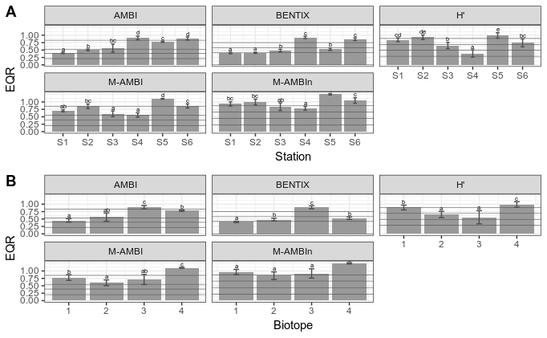

```r
(plot.comp.ind.st.sbiotope.summary.sand <- cowplot::plot_grid(plot.ind.st.summary.sand,
                                                              plot.ind.biotope.summary.sand,
                                                              nrow = 2,
                                                              align = "h", labels = c("A", "B"))
)
```

Save this monstrosity.

```r
cowplot::save_plot(here(figures.dir, "ind_st_biotope_summary_sand.png"),
                   plot.comp.ind.st.sbiotope.summary.sand,
                   base_aspect_ratio = 2, base_width = 6.8, base_height = 6)
```

Better idea: instead of having the ES limits as lines, do them as strips of colour. Might be a more intuitive visualization.. Also plot the mean EQRs as dots instead of bars (bars are generally a waste of ink).

```r
## we want ranges (ymin-ymax) to plot the classes as strips of colour. The values in the index limit tibble are the lower limits of each class = ymin (except for bad, which is 0 and will have to be added). The upper limits are Inf for high, and the lower limit of the previous class for all others. Bonus: will be the same for the seagrasses, so won't have to repeat this calculation.
(ind.limits.strips.long <- ind.limits.long %>%
   ## add a row of 0 for each index - corresponding to the lower limit for the bad class
   bind_rows(tibble(index = c("H'", "AMBI", "M-AMBI", "BENTIX", "M-AMBIn"),
                    limits = rep(0, times = 5))) %>%
   arrange(index) %>%
   group_by(index) %>%
   ## calculate the ymin and ymax for each index, as described above
   mutate(ymin = limits,
          ymax = lag(limits, 1)) %>%
   ## set ymax for high to +Inf
   mutate(ymax = replace_na(ymax, Inf)) %>%
   ## add class designation (as factor) - to be used in the plot legend
   mutate(class = factor(c("high", "good", "moderate", "poor", "bad"), levels = c("high", "good", "moderate", "poor", "bad")))
)
```

| index | limits | ymin | ymax | class |
| --- | --- | --- | --- | --- |
| AMBI | 0.83 | 0.83 | Inf | high |
| AMBI | 0.53 | 0.53 | 0.83 | good |
| AMBI | 0.39 | 0.39 | 0.53 | moderate |
| AMBI | 0.21 | 0.21 | 0.39 | poor |
| AMBI | 0.00 | 0.00 | 0.21 | bad |
| BENTIX | 0.75 | 0.75 | Inf | high |
| BENTIX | 0.58 | 0.58 | 0.75 | good |
| BENTIX | 0.42 | 0.42 | 0.58 | moderate |
| BENTIX | 0.00 | 0.00 | 0.42 | poor |
| BENTIX | 0.00 | 0.00 | 0.00 | bad |

[output cut: 15 more lines]

```r
## make a new named vector of colours for the classes (yes I know it's technically the same as the EG colours, in fact I'm reusing it, but I don't want too much confusion)
es.classes <- eg.colours
names(es.classes) <- as.character(levels(ind.limits.strips.long$class))
```

On to the monstrous plot!

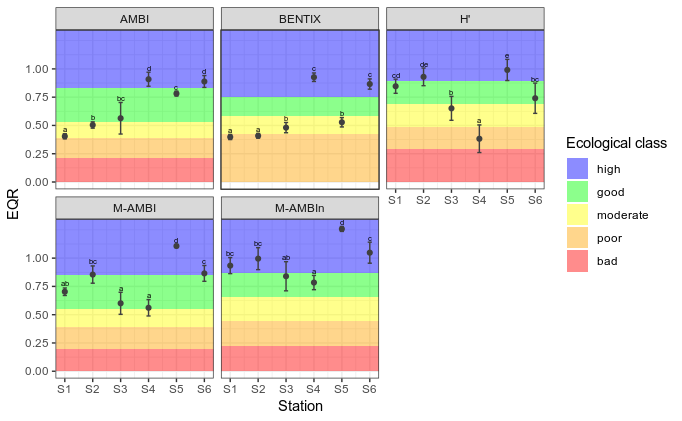

```r
(plot.ind.st.summary.strips.sand <- ggplot(ind.st.summary.sand.long,
                                           aes(x = as.numeric(station), y = mean)) +
   ## add the strips first - so as to form the background, not overlap the points
   geom_rect(data = ind.limits.strips.long,
             aes(xmin = -Inf, xmax = Inf, ymin = ymin, ymax = ymax, fill = class),
             alpha = 0.45, inherit.aes = FALSE) +
   scale_fill_manual(name = "Ecological class", values = es.classes) +

   ## error bars = sd. Plot first, so as to go behind the dots
   geom_errorbar(aes(ymin = mean - sd, ymax = mean + sd),
                 width = 0.15, colour = "grey25", position = position_dodge(0.9)) +
   geom_point(colour = "grey25") +
   ## labels - significant difference pairs (above error bars)
   geom_text(aes(x = as.numeric(station), y = mean + sd, label = label), vjust = -0.3, size = 2) +
   labs(x = "Station", y = "EQR") +
   facet_wrap(~index) +
   scale_y_continuous(breaks = seq(0, 1, 0.25)) +
   scale_x_continuous(breaks = 1:6, labels = paste0("S", unique(as.numeric(ind.st.summary.sand.long$station))))
)
```

Save this - wow was it a pain to construct, I really don’t want to lose it somewhere…

```r
ggsave(here(figures.dir, "ind_station_summary_strips_sand.png"),
       plot.ind.st.summary.strips.sand,
       dpi = 300, width = 17, height = 15, units = "cm")
```

Now plot the biotopes (keeping the x axis numeric for readability).

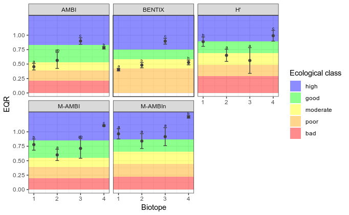

```r
(plot.ind.biotope.summary.strips.sand <- ggplot(ind.biotope.summary.sand.long,
                                                aes(x = as.numeric(biotope), y = mean)) +
   ## add the strips first - so as to form the background, not overlap the points
   geom_rect(data = ind.limits.strips.long,
             aes(xmin = -Inf, xmax = Inf, ymin = ymin, ymax = ymax, fill = class),
             alpha = 0.45, inherit.aes = FALSE) +
   scale_fill_manual(name = "Ecological class", values = es.classes) +

   ## error bars = sd. Before the points, so that the bars don't overlap them
   geom_errorbar(aes(ymin = mean - sd, ymax = mean + sd),
                 width = 0.15, colour = "grey25", position = position_dodge(0.9)) +
   geom_point(colour = "grey25") +

   ## labels - significant differences between pairs
   geom_text(aes(x = as.numeric(biotope), y = mean + sd, label = label), vjust = -0.3, size = 2) +

   labs(x = "Biotope", y = "EQR") +
   facet_wrap(~index) +
   scale_y_continuous(breaks = seq(0, 1, 0.25)) +
   scale_x_continuous(breaks = 1:4)
)
```

Save this one, too.

```r
ggsave(here(figures.dir, "ind_biotope_summary_strips_sand.png"),
       plot.ind.biotope.summary.strips.sand,
       dpi = 300, width = 17, height = 15, units = "cm")
```

Make a composite plot of both stations and biotopes, with EC as colour strips.

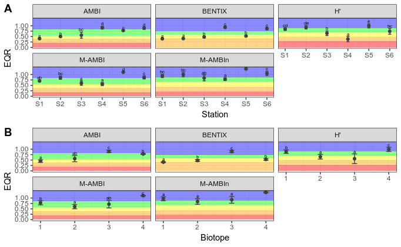

```r
(plot.comp.ind.st.biotope.summary.strips.sand <- cowplot::plot_grid(plot.ind.st.summary.strips.sand + theme(legend.position = "none"),
                                                                    plot.ind.biotope.summary.strips.sand + theme(legend.position = "none"),
                                                                    nrow = 2,
                                                                    align = "h", labels = c("A", "B"))
)
```

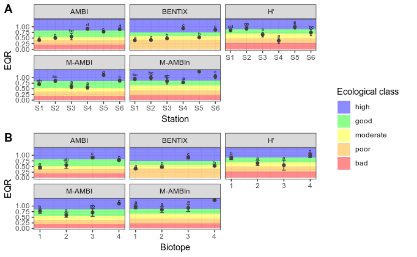

```r
## get the legend from one of the plots, and put it at the bottom
comp.ind.legend <- cowplot::get_legend(plot.ind.biotope.summary.strips.sand + theme(legend.position = "right"))

(plot.comp.ind.st.biotope.summary.strips.sand <- cowplot::plot_grid(plot.comp.ind.st.biotope.summary.strips.sand,
                                                  comp.ind.legend,
                                                  ncol = 2, rel_widths = c(1, 0.3))
)
```

Save this monstrosity.

```r
cowplot::save_plot(here(figures.dir, "ind_st_biotope_summary_strips_sand.png"),
                   plot.comp.ind.st.biotope.summary.strips.sand,
                   base_aspect_ratio = 2, base_width = 6.8, base_height = 7)
```

##### Index performance vs environmental parameters

###### **Normalize indices (MEDGIG)**

We’ll normalize the index EQRs before going on to compare them among themselves & with the environmental parameters, as was done in the MEDGIG intercalibrations (van de Bund et al. 2008).

| H.EQR | AMBI.EQR | M-AMBI | BENTIX.EQR | M-AMBIn.EQR |
| --- | --- | --- | --- | --- |
| 0.8363636 | 0.4871429 | 0.7126667 | 0.4150000 | 0.9830769 |
| 0.7090000 | 0.3955556 | 0.7126667 | 0.3809524 | 0.8246154 |
| 0.8654545 | 0.4328571 | 0.7126667 | 0.3938095 | 1.0092308 |
| 0.7640000 | 0.4085714 | 0.6726667 | 0.3804762 | 0.9076923 |
| 0.6580000 | 0.4085714 | 0.6726667 | 0.3790476 | 0.7857143 |
| 0.7890000 | 0.4500000 | 0.6726667 | 0.3980952 | 0.8846154 |
| 0.6760000 | 0.3844444 | 0.7206667 | 0.3752381 | 0.7485714 |
| 0.7900000 | 0.4057143 | 0.7206667 | 0.3985714 | 1.0430769 |
| 0.7690000 | 0.4185714 | 0.7206667 | 0.3933333 | 0.9369231 |
| 0.6820000 | 0.6066667 | 0.8133333 | 0.4012500 | 0.7533333 |

[output cut: 44 more lines]

###### **Correlation with environmental parameters**

Good, useful biotic indices respond to changes in community structure related to pressure (natural or anthropogenic). Therefore, in a pressure gradient such as the one in Burgas Bay (demonstrated by the change in environmental variables & LUSI), they are expected to be correlated with the the environmental parameters: negatively with the eutrophication & pollution indicators & LUSI, positively with parameters such as dissolved O2, water transparency etc. The performance won’t be terribly good anyway because of the natural variability of the communities (see previous analyses by biotope).

Import environmental data for sand.  
Again, as before, I’ll use the most significant ones determined by PCA: LUSI, secchi, seston, PO4, NH4, NO3 + all sediment parameters (except the most inter-correlated): TOM, moisture content, gravel and silt_clay.  
Import the environmental parameters (from the cleaned files; see multivariate analyses notebook).

| station | NH4 | NO3 | PO4 | seston | secchi | LUSI | TOM | moisture_content | gravel | silt_clay |
| --- | --- | --- | --- | --- | --- | --- | --- | --- | --- | --- |
| Kraimorie | 1.09 | 2.63 | 0.34 | 2.29 | 3.27 | 6.25 | 2.668743 | 24.96006 | 29.2910811 | 7.4802569 |
| Kraimorie | 1.09 | 2.63 | 0.34 | 2.29 | 3.27 | 6.25 | 2.668743 | 24.96006 | 29.2910811 | 7.4802569 |
| Kraimorie | 1.09 | 2.63 | 0.34 | 2.29 | 3.27 | 6.25 | 2.668743 | 24.96006 | 29.2910811 | 7.4802569 |
| Kraimorie | 1.09 | 2.63 | 0.34 | 2.29 | 3.27 | 6.25 | 2.320585 | 26.37882 | 34.4206293 | 4.0770747 |
| Kraimorie | 1.09 | 2.63 | 0.34 | 2.29 | 3.27 | 6.25 | 2.320585 | 26.37882 | 34.4206293 | 4.0770747 |
| Kraimorie | 1.09 | 2.63 | 0.34 | 2.29 | 3.27 | 6.25 | 2.320585 | 26.37882 | 34.4206293 | 4.0770747 |
| Kraimorie | 1.09 | 2.63 | 0.34 | 2.29 | 3.27 | 6.25 | 3.016901 | 23.54131 | 24.1615329 | 10.8834391 |
| Kraimorie | 1.09 | 2.63 | 0.34 | 2.29 | 3.27 | 6.25 | 3.016901 | 23.54131 | 24.1615329 | 10.8834391 |
| Kraimorie | 1.09 | 2.63 | 0.34 | 2.29 | 3.27 | 6.25 | 3.016901 | 23.54131 | 24.1615329 | 10.8834391 |
| Chukalya | 0.96 | 2.35 | 0.32 | 2.42 | 4.39 | 4.00 | 1.707946 | 26.45092 | 19.3405824 | 2.6056875 |

[output cut: 44 more lines]

Calculate the correlations..

```r
ind.corr.env.sand <- Hmisc::rcorr(as.matrix(bind_cols(indices.all.norm.sand, S = indices.all.sand$S)), # also include S - as suggested by article review
                                  as.matrix(env.data.sand %>% dplyr::select(-station)),
                                  type = "spearman")


corstars <- function(corr.result) {
  ### helper to label the significant correlations with the corresponding number of stars (source: http://myowelt.blogspot.bg/2008/04/beautiful-correlation-tables-in-r.html)
  ### Arguments: corr.result - list of correlation results obtained by Hmisc::corr

    ## extract the correlation coefficients and p-values from the list
    r <- corr.result$r
    p <- corr.result$P ## mind the capital P!

    ## define notions for significance levels; spacing is important.
    stars <- ifelse(p < 0.001, "***",
                    ifelse(p < 0.01, "**",
                           ifelse(p < 0.05, "*", "")))

    ## truncate the matrix that holds the correlations to two decimals
    r <- round(r, 2)

    ## build a new matrix that includes the correlations with their appropriate stars
    rstars <- matrix(paste(as.character(r), stars, sep = ""), ncol = ncol(r))

    diag(rstars) <- diag(r)
    rownames(rstars) <- rownames(r)
    colnames(rstars) <- colnames(r)

    ## remove upper triangle
    rstars[upper.tri(rstars, diag = TRUE)] <- ""
    rstars <- as.data.frame(rstars)

    ## remove last column and return the now-data frame
    rstars <- rstars[1:length(rstars) - 1]
    return(rstars)
}

corstars(ind.corr.env.sand)
```

|  | H.EQR | AMBI.EQR | M-AMBI | BENTIX.EQR | M-AMBIn.EQR | S | NH4 | NO3 | PO4 | seston | secchi | LUSI | TOM | moisture_content | gravel |
| --- | --- | --- | --- | --- | --- | --- | --- | --- | --- | --- | --- | --- | --- | --- | --- |
| H.EQR |  |  |  |  |  |  |  |  |  |  |  |  |  |  |  |
| AMBI.EQR | -0.37** |  |  |  |  |  |  |  |  |  |  |  |  |  |  |
| M-AMBI | 0.77*** | 0.09 |  |  |  |  |  |  |  |  |  |  |  |  |  |
| BENTIX.EQR | -0.48*** | 0.91*** | -0.11 |  |  |  |  |  |  |  |  |  |  |  |  |
| M-AMBIn.EQR | 0.83*** | 0.07 | 0.9*** | -0.07 |  |  |  |  |  |  |  |  |  |  |  |
| S | 0.84*** | -0.24 | 0.79*** | -0.35* | 0.89*** |  |  |  |  |  |  |  |  |  |  |
| NH4 | 0.38** | -0.9*** | -0.09 | -0.9*** | -0.08 | 0.23 |  |  |  |  |  |  |  |  |  |
| NO3 | 0.09 | -0.11 | -0.07 | -0.12 | -0.05 | 0.13 | 0.31* |  |  |  |  |  |  |  |  |
| PO4 | 0.12 | -0.82*** | -0.35** | -0.78*** | -0.33* | -0.04 | 0.94*** | 0.37** |  |  |  |  |  |  |  |
| seston | 0.17 | -0.75*** | -0.27 | -0.77*** | -0.29* | -0.06 | 0.89*** | 0.2 | 0.94*** |  |  |  |  |  |  |

[output cut: 6 more lines]

```r
## kable(corstars(ind.corr.env.sand)) # better-looking table
```

**NB M-AMBIn**  
M-AMBI*n is a special case: it has superceded M-AMBI in the national monitoring since 2015, but does not yet have ecological class limits for all biotopes. Case in point - in this study, two biotopes have limits, and two do not.  
To prove that when the limits **are** adjusted for the particular characteristics of the biotope, the index functions well, we’ll calculate its correlations with the environmental parameters; however, we’ll only include the high-confidence samples (those from biotopes with adapted ES limits - st. 3, 4, 6) - and recalculate.

NB The index values here are NOT normalized (still not sure if they should be - as far as I can tell, it’s only useful/justified for pairwise comparisons of indices as in the intercalibration). If this is the case, then the previous correlation matrix is wrong and should be redone using non-normalized index values.

|  | M-AMBIn.EQR | NH4 | NO3 | PO4 | seston | secchi | LUSI | TOM | moisture_content | gravel |
| --- | --- | --- | --- | --- | --- | --- | --- | --- | --- | --- |
| M-AMBIn.EQR |  |  |  |  |  |  |  |  |  |  |
| NH4 | -0.56** |  |  |  |  |  |  |  |  |  |
| NO3 | -0.19 | -0.5** |  |  |  |  |  |  |  |  |
| PO4 | -0.56** | 1*** | -0.5** |  |  |  |  |  |  |  |
| seston | -0.56** | 1*** | -0.5** | 1*** |  |  |  |  |  |  |
| secchi | 0.56** | -1*** | 0.5** | -1*** | -1*** |  |  |  |  |  |
| LUSI | -0.56** | 1*** | -0.5** | 1*** | 1*** | -1*** |  |  |  |  |
| TOM | 0.47* | -0.95*** | 0.47* | -0.95*** | -0.95*** | 0.95*** | -0.95*** |  |  |  |
| moisture_content | 0.47* | -0.95*** | 0.47* | -0.95*** | -0.95*** | 0.95*** | -0.95*** | 1*** |  |  |
| gravel | -0.62*** | 0.58** | -0.05 | 0.58** | 0.58** | -0.58** | 0.58** | -0.67*** | -0.67*** |  |

[output cut: 1 more lines]

This is much, much better than before - significant negative correlations with the eutrophication parameteres & LUSI and sediment silt-clay, and significant positive with water transparency. Not good - significant correlation with TOM, but it has only been measured 3 times during this study, and not even that sometimes, so not much can be expected. Also a bit strange - inclusion of the other sediment parameters (gravel, moisture content) - they’re not really indicative of any sort of pressure (in fact, they’re a remnant of the community structure analyses, where they do serve a purpose).

**NOTE 2019/05/07: I checked with the published article on this - there are some discrepancies in the correlation coefficients and significance levels (and also with the environmental parameters used). I suppose it’s because for the thesis, I redid most of the calculations, and notably imputed (mean value) the missing values for the sediment parameters - there is so little data there anyway.. I don’t know what precisely is going on with the NO3 for instance. For practical purposes, I am going with the published results in the article - NOT the ones obtained here; and with the parameters there, too. In any case, they aren’t too different - the conclusions are exactly the same - and it will be too much hassle to explain the mismatch.**

Last-last thing to try: given the environmental parameters, check if the classification system successfully differentiates between between classes, and between which subsequent classes - best?  
I’m only going to use the environmental parameters with which the indices have the best correlations (yes, I know it is highly subjective, and I don’t care). Also, I’m importing and using the **old environmental data from the article**. Import the old environmental data (pre-cleaned and everything).

```r
(env.data.old.sand <- read_csv(here(data.dir, "env_data_smry_old_sand.csv"))
)
```

| station | Ntot_mean | NO3_mean | NH4_mean | PO4_mean | chl.a_mean | seston_mean | Secchi.depth_mean | org.matter | mean.grain.size | silt.clay | O2.bottom | LUSI |
| --- | --- | --- | --- | --- | --- | --- | --- | --- | --- | --- | --- | --- |
| Kraimorie | 18.93987 | 2.609411 | 1.0933333 | 0.3354826 | 3.225497 | 2.286936 | 3.268000 | NA | NA | NA | 6.59 | 6.25 |
| Kraimorie | 18.93987 | 2.609411 | 1.0933333 | 0.3354826 | 3.225497 | 2.286936 | 3.268000 | NA | NA | NA | 6.59 | 6.25 |
| Kraimorie | 18.93987 | 2.609411 | 1.0933333 | 0.3354826 | 3.225497 | 2.286936 | 3.268000 | NA | NA | NA | 6.59 | 6.25 |
| Kraimorie | 18.93987 | 2.609411 | 1.0933333 | 0.3354826 | 3.225497 | 2.286936 | 3.268000 | 2.320585 | 236.88379 | 4.0770747 | 7.76 | 6.25 |
| Kraimorie | 18.93987 | 2.609411 | 1.0933333 | 0.3354826 | 3.225497 | 2.286936 | 3.268000 | 2.320585 | 236.88379 | 4.0770747 | 7.76 | 6.25 |
| Kraimorie | 18.93987 | 2.609411 | 1.0933333 | 0.3354826 | 3.225497 | 2.286936 | 3.268000 | 2.320585 | 236.88379 | 4.0770747 | 7.76 | 6.25 |
| Kraimorie | 18.93987 | 2.609411 | 1.0933333 | 0.3354826 | 3.225497 | 2.286936 | 3.268000 | 3.016901 | 224.65650 | 10.8834391 | 3.11 | 6.25 |
| Kraimorie | 18.93987 | 2.609411 | 1.0933333 | 0.3354826 | 3.225497 | 2.286936 | 3.268000 | 3.016901 | 224.65650 | 10.8834391 | 3.11 | 6.25 |
| Kraimorie | 18.93987 | 2.609411 | 1.0933333 | 0.3354826 | 3.225497 | 2.286936 | 3.268000 | 3.016901 | 224.65650 | 10.8834391 | 3.11 | 6.25 |
| Chukalya | 18.60505 | 2.349450 | 0.9593333 | 0.3159741 | 3.086801 | 2.423337 | 4.388000 | NA | 223.11551 | 2.6056875 | 6.72 | 4.00 |

[output cut: 44 more lines]

Gather the needed data (yes, I’m making another two-three-million useless temporary data frames).

```r
## get the index EQRs, and convert to qualitative. MAKE EXTRA SURE THE COLUMNS ARE IN THE SAME ORDER IN THE TWO DFS, OTHERWISE THE WRONG LIMITS WILL BE APPLIED TO EACH INDEX
(ind.qual.sand <- map2_df(indices.all.norm.sand %>% select(H.EQR, AMBI.EQR, `M-AMBI`, BENTIX.EQR, `M-AMBIn.EQR`),
                             ind.limits,
                             ~es_qualitative(.x, .y)
                             )
)
```

| H.EQR | AMBI.EQR | M-AMBI | BENTIX.EQR | M-AMBIn.EQR |
| --- | --- | --- | --- | --- |
| good | moderate | good | poor | high |
| good | moderate | good | poor | good |
| good | moderate | good | poor | high |
| good | moderate | good | poor | high |
| moderate | moderate | good | poor | good |
| good | moderate | good | poor | high |
| moderate | poor | good | poor | good |
| good | moderate | good | poor | high |
| good | moderate | good | poor | high |
| moderate | good | good | poor | good |

[output cut: 44 more lines]

```r
## get (manually) the environmental parameters, and add to the qualitative index df. AGAIN MAKE SURE THE ROWS ARE IN THE SAME ORDER (I TRUST THEY ARE HERE, BUT IN FUTURE)
(ind.qual.env.sand <- bind_cols(ind.qual.sand,
                                   env.data.old.sand %>% select(silt.clay, Secchi.depth_mean, chl.a_mean, NH4_mean, PO4_mean, LUSI))
)
```

| H.EQR | AMBI.EQR | M-AMBI | BENTIX.EQR | M-AMBIn.EQR | silt.clay | Secchi.depth_mean | chl.a_mean | NH4_mean | PO4_mean | LUSI |
| --- | --- | --- | --- | --- | --- | --- | --- | --- | --- | --- |
| good | moderate | good | poor | high | NA | 3.268000 | 3.225497 | 1.0933333 | 0.3354826 | 6.25 |
| good | moderate | good | poor | good | NA | 3.268000 | 3.225497 | 1.0933333 | 0.3354826 | 6.25 |
| good | moderate | good | poor | high | NA | 3.268000 | 3.225497 | 1.0933333 | 0.3354826 | 6.25 |
| good | moderate | good | poor | high | 4.0770747 | 3.268000 | 3.225497 | 1.0933333 | 0.3354826 | 6.25 |
| moderate | moderate | good | poor | good | 4.0770747 | 3.268000 | 3.225497 | 1.0933333 | 0.3354826 | 6.25 |
| good | moderate | good | poor | high | 4.0770747 | 3.268000 | 3.225497 | 1.0933333 | 0.3354826 | 6.25 |
| moderate | poor | good | poor | good | 10.8834391 | 3.268000 | 3.225497 | 1.0933333 | 0.3354826 | 6.25 |
| good | moderate | good | poor | high | 10.8834391 | 3.268000 | 3.225497 | 1.0933333 | 0.3354826 | 6.25 |
| good | moderate | good | poor | high | 10.8834391 | 3.268000 | 3.225497 | 1.0933333 | 0.3354826 | 6.25 |
| moderate | good | good | poor | good | 2.6056875 | 4.388000 | 3.086801 | 0.9593333 | 0.3159741 | 4.00 |

[output cut: 44 more lines]

```r
## convert to long, key = index
(ind.qual.env.long.sand <- gather(ind.qual.env.sand, key = "index", value = "assessment", -c(silt.clay:LUSI)) %>%
    ## convert the qualitative assessments to factor, so that the classes go high to bad
    mutate(assessment = factor(assessment, levels = c("high", "good", "moderate", "poor", "bad")))
)
```

| silt.clay | Secchi.depth_mean | chl.a_mean | NH4_mean | PO4_mean | LUSI | index | assessment |
| --- | --- | --- | --- | --- | --- | --- | --- |
| NA | 3.268000 | 3.225497 | 1.0933333 | 0.3354826 | 6.25 | H.EQR | good |
| NA | 3.268000 | 3.225497 | 1.0933333 | 0.3354826 | 6.25 | H.EQR | good |
| NA | 3.268000 | 3.225497 | 1.0933333 | 0.3354826 | 6.25 | H.EQR | good |
| 4.0770747 | 3.268000 | 3.225497 | 1.0933333 | 0.3354826 | 6.25 | H.EQR | good |
| 4.0770747 | 3.268000 | 3.225497 | 1.0933333 | 0.3354826 | 6.25 | H.EQR | moderate |
| 4.0770747 | 3.268000 | 3.225497 | 1.0933333 | 0.3354826 | 6.25 | H.EQR | good |
| 10.8834391 | 3.268000 | 3.225497 | 1.0933333 | 0.3354826 | 6.25 | H.EQR | moderate |
| 10.8834391 | 3.268000 | 3.225497 | 1.0933333 | 0.3354826 | 6.25 | H.EQR | good |
| 10.8834391 | 3.268000 | 3.225497 | 1.0933333 | 0.3354826 | 6.25 | H.EQR | good |
| 2.6056875 | 4.388000 | 3.086801 | 0.9593333 | 0.3159741 | 4.00 | H.EQR | moderate |

[output cut: 260 more lines]

Make a boxplot of the distribution of classes vs the environmental parameters for each index.

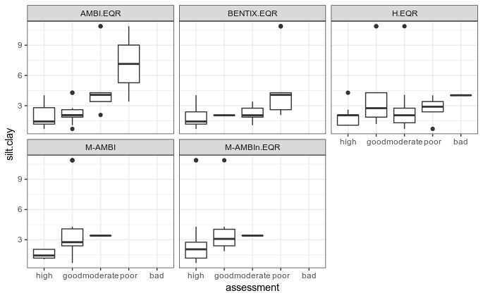

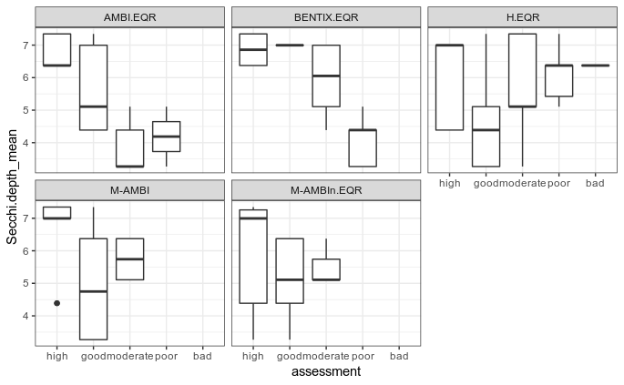

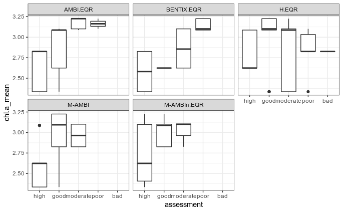

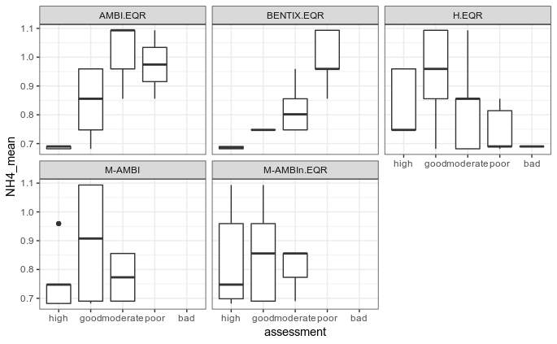

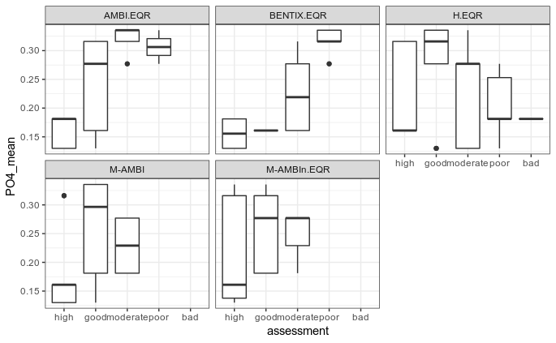

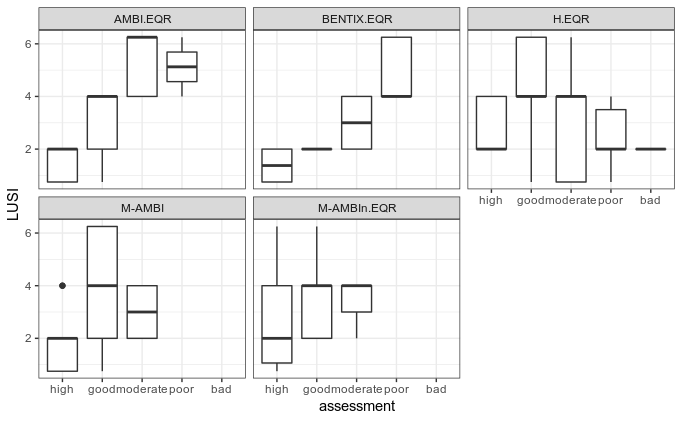

```r
## to avoid repeating code for each variable, AND to have nice y-axis labels..
map2(ind.qual.env.long.sand %>% select(silt.clay:LUSI),
     names(ind.qual.env.long.sand %>% select(silt.clay:LUSI)),
     ~ggplot(ind.qual.env.long.sand, aes(x = assessment, y = .x)) +
       geom_boxplot() +
       labs(y = .y) +
       facet_wrap(~index))
```

I don’t think I’m using this, in the end.. That’s why I’m not going to try and make the plots more presentable.  
As expected from the correlations - for some index-parameter combinations, not bad at all - classification distinct enough, and in the correct direction to boot. See AMBI (and BENTIX, though a bit less) with silt.clay, chl.a, secchi, LUSI. The other three are shitty, though - H’ and M-AMBI for the reasons already explained, M-AMBIn because not adjusted for most of the habitat subtypes in the dataset.  
Funny thing - no bad anywhere (some in H, which as established performs really poorly in some particular conditions which I was unlucky enough to get in my data).

###### **Index agreement analyses**

Not only are indices supposed to react to changes in benthic community structure, they should also agree with each other, so that they can be applied with good confidence in the study area, and the assessments are comparable with those coming from other areas (i.e., “good” means the same thing everywhere).  
This was the principle behind the various intercalibrations - make sure all assessments mean the same thing. To test it here, the suggested procedures / indicators from van de Bund et al. (2008) will be applied: the absolute average class difference and the percentage agreement (as supporting measure).

```r
ind.abs.class.diff.sand
```

```
    H.EQR-AMBI.EQR H.EQR-M-AMBI H.EQR-BENTIX.EQR H.EQR-M-AMBIn.EQR AMBI.EQR-M-AMBI
V1               2            1                2                 0               1
V2               2            0                2                 1               2
V3               2            1                3                 0               1
V4               1            0                2                 1               1
V5               1            0                2                 0               1
V6               1            0                2                 1               1
V7               2            0                2                 0               2
V8               1            0                2                 1               1
V9               1            0                2                 1               1
V10              0            1                1                 0               1
V11              2            0                3                 0               2
V12              2            0                2                 0               2
V13              2            1                3                 0               1
V14              2            1                3                 0               1
V15              1            0                2                 1               1
V16              1            0                2                 0               1
V17              2            0                3                 0               2
V18              2            0                3                 0               2
V19              0            0                0                 1               0
V20              0            0                0                 1               0
V21              1            0                0                 0               1
V22              0            0                1                 1               0
V23              0            0                1                 0               0
V24              0            0                1                 1               0
V25              1            1                0                 2               0
V26              1            1                0                 2               0
V27              0            0                1                 1               0
V28              4            2                4                 3               2
V29              3            1                3                 2               2
V30              4            2                4                 3               2
V31              3            2                3                 2               1
V32              3            2                3                 2               1
V33              4            3                4                 3               1
V34              2            1                2                 1               1
V35              1            1                2                 1               0
V36              3            2                3                 3               1
V37              1            0                2                 0               1
V38              1            0                2                 0               1
V39              1            0                2                 0               1
```

[output cut: 110 more lines]

```
V40                      2
V41                      2
V42                      2
V43                      1
V44                      2
V45                      2
V46                      0
V47                      0
V48                      0
V49                      0
V50                      0
V51                      0
V52                      0
V53                      0
V54                      0
```

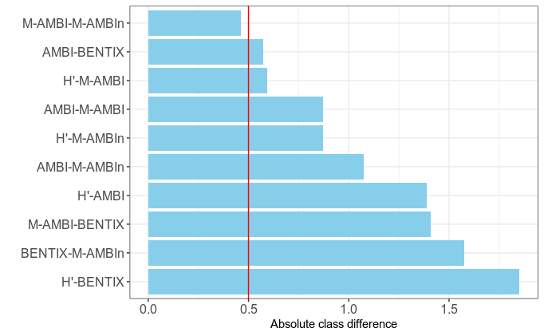

This is interesting..  
The highest agreement is between M-AMBI and M-AMBIn - the only acceptable one, really.. Didn’t much expect that. Might be due to the lack of appropriate ES boundaries for half the biotopes in my dataset.  
Then, H’ and M-AMBIn have a relatively low agreement - same as AMBI and M-AMBI, actually. This is cool - H’ is no longer the dominant component in the formation of the assessment by M-AMBIn Considering its shortcomings (non-linear reaction to community changes, susceptibility to dominance in the communities, dependence on sampling effort), this is a good thing.  
M-AMBIn and BENTIX also don’t really agree at all - it’s even worse than the agreement with M-AMBI. BENTIX really only likes to play with AMBI - understandable, since it’s an AMBI variation.

Save the plot.

```r
ggsave(here(figures.dir, "ind_abs_class_diff_sand.png"),
       plot.ind.abs.av.class.diff.sand,
       dpi = 300, width = 16, height = 15, units = "cm")
```

Calculate the percentage agreement between indices.

```r
## summarize the calculated class differences (for 5 classes)
ind.percent.agreement.sand <- as_tibble(ind.abs.class.diff.sand) %>%
    gather(key = ind, value = diff) %>%
    ## recode the class difference so that all differences of > 2 classes form a single group
    mutate(diff = recode(diff, "0" = 0, "1" = 1, "2" = 2, "3" = 3, "4" = 3)) %>%
    group_by(ind, diff) %>%
    summarize(count = n()) %>%
    ungroup()

## calculate the % agreement
ind.percent.agreement.sand <- ind.percent.agreement.sand %>%
  group_by(ind) %>%
  mutate(percent_agr = count/sum(count) * 100)

## fix names a bit (as before)
(ind.percent.agreement.sand <- ind.percent.agreement.sand %>%
    ungroup() %>%
    mutate(ind = gsub(".EQR", "", x = ind)) %>%
    mutate(ind = gsub("H", "H'", x = ind)) %>%
    arrange(diff, desc(percent_agr))
)
```

| ind | diff | count | percent_agr |
| --- | --- | --- | --- |
| H'-M-AMBI | 0 | 30 | 55.555556 |
| M-AMBI-M-AMBIn | 0 | 29 | 53.703704 |
| AMBI-BENTIX | 0 | 23 | 42.592593 |
| H'-M-AMBIn | 0 | 23 | 42.592593 |
| AMBI-M-AMBI | 0 | 16 | 29.629630 |
| AMBI-M-AMBIn | 0 | 12 | 22.222222 |
| BENTIX-M-AMBIn | 0 | 11 | 20.370370 |
| H'-AMBI | 0 | 10 | 18.518519 |
| M-AMBI-BENTIX | 0 | 9 | 16.666667 |
| H'-BENTIX | 0 | 6 | 11.111111 |

[output cut: 25 more lines]

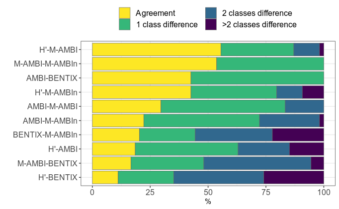

```r
## we'll plot as stacked bar chart with fill colors by level of agreement (diff); we need to put the fill factor in descending order, because ggplot stacks bottom to top.
ind.percent.agreement.sand <- ind.percent.agreement.sand %>%
    mutate(diff = factor(diff, levels = rev(0:3))) %>%
    mutate(ind = factor(ind, levels = rev(unique(ind)))) # in reverse order, so that on the plot, they'll come out arranged by highest % perfect agreement (diff = 0)

## plot
(plot.ind.percent.agr.sand <- ggplot(ind.percent.agreement.sand,
                                     aes(x = ind, y = percent_agr, fill = diff)) +
        geom_bar(stat = "identity", colour = "grey40", size = 0.25) +
        # very ugly padding hack to increase spacing of legend items:
        scale_fill_viridis(discrete = T, name = "",
                           labels = c(" >2 classes difference  ",
                                      " 2 classes difference  ",
                                      " 1 class difference  ",
                                      " Agreement  ")) +
        labs(x = "", y = "%") +
        coord_flip() +
        guides(fill = guide_legend(reverse = TRUE, nrow = 2, byrow = FALSE)) + # reverse the order of the legend, it gets messed up when putting it on top
        theme(legend.position = "top") +
        text_size(text.x = 12, text.y = 12, legend.text = 12, title.y = 12)
)
```

Well, as expected, based on the previous analysis.. The same pairs have the highest % agreement, and most often - only 1 class difference.. Then, from H’-M-AMBIn down - all over the place; it’s like they go completely random, evenly spread across classes.

Save this plot.

```r
ggsave(here(figures.dir, "ind_perc_agreement_sand.png"),
       dpi = 300, width = 16, height = 15, units = "cm")
```

Check in how many cases the diffences cross the good-moderate border - that would be the one requiring measures to be taken.

```r
## custom function, and a pain in the ass it was to write. Also probably could have been done much more easily and elegantly.
gm.diff.sand <- gm_diff(indices.all.norm.sand, ind.limits)

## fix index names, because I have OCD
(gm.diff.sand <- gm.diff.sand %>%
    mutate(contrast = str_replace_all(contrast, pattern = ".EQR", replacement = ""))
)
```

| contrast | gm_diff |
| --- | --- |
| H-AMBI | 0.55555556 |
| H-M-AMBI | 0.37037037 |
| H-BENTIX | 0.72222222 |
| H-M-AMBIn | 0.42592593 |
| AMBI-M-AMBI | 0.25925926 |
| AMBI-BENTIX | 0.38888889 |
| AMBI-M-AMBIn | 0.24074074 |
| M-AMBI-BENTIX | 0.64814815 |
| M-AMBI-M-AMBIn | 0.05555556 |
| BENTIX-M-AMBIn | 0.62962963 |

#### **Seagrass stations (Burgas Bay, 2013-2014)**

Import zoobenthic abundance data (cleaned and prepared).

| station | month | year | habitat | replicate | Abra alba | Abra prismatica | Abra segmentum | Abra sp. | Acanthocardia tuberculata | Acari | Actiniaria | Alitta succinea | Ampelisca diadema | Ampharetidae | Amphibalanus improvisus | Amphipoda | Amphitritides gracilis | Ampithoe sp. | Anadara kagoshimensis | Aonides paucibranchiata | Apherusa bispinosa | Apseudopsis ostroumovi | Aricidea claudiae | Bathyporeia guilliamsoniana | Bittium reticulatum | Bivalvia undet. | Bodotria arenosa | Brachynotus sexdentatus | Brachystomia scalaris | … |
| --- | --- | --- | --- | --- | --- | --- | --- | --- | --- | --- | --- | --- | --- | --- | --- | --- | --- | --- | --- | --- | --- | --- | --- | --- | --- | --- | --- | --- | --- | --- |
| Poda | 6 | 2013 | Z | a | 13 | 0 | 0 | 0 | 0 | 0 | 1 | 15 | 13 | 0 | 2 | 0 | 0 | 0 | 0 | 0 | 0 | 0 | 0 | 0 | 0 | 0 | 0 | 0 | 0 | … |
| Poda | 6 | 2013 | Z | b | 8 | 0 | 0 | 0 | 0 | 0 | 0 | 7 | 4 | 0 | 20 | 0 | 0 | 0 | 0 | 0 | 0 | 0 | 0 | 0 | 10 | 0 | 0 | 1 | 0 | … |
| Poda | 6 | 2013 | Z | c | 4 | 0 | 0 | 0 | 0 | 0 | 0 | 6 | 25 | 0 | 2 | 0 | 0 | 0 | 0 | 0 | 0 | 0 | 0 | 0 | 4 | 0 | 0 | 0 | 0 | … |
| Poda | 6 | 2013 | Z | d | 5 | 0 | 0 | 0 | 0 | 0 | 0 | 17 | 14 | 0 | 1 | 0 | 0 | 0 | 0 | 0 | 0 | 0 | 0 | 0 | 6 | 0 | 0 | 0 | 0 | … |
| Poda | 7 | 2014 | Z | a | 3 | 0 | 0 | 0 | 0 | 0 | 0 | 0 | 9 | 0 | 3 | 0 | 0 | 0 | 0 | 0 | 0 | 0 | 0 | 0 | 49 | 0 | 0 | 0 | 0 | … |
| Poda | 7 | 2014 | Z | b | 5 | 0 | 0 | 0 | 0 | 0 | 0 | 4 | 5 | 0 | 4 | 0 | 0 | 0 | 0 | 0 | 0 | 0 | 0 | 0 | 177 | 0 | 0 | 0 | 0 | … |
| Poda | 7 | 2014 | Z | c | 9 | 0 | 0 | 0 | 0 | 0 | 0 | 6 | 4 | 0 | 7 | 0 | 0 | 0 | 1 | 0 | 0 | 0 | 0 | 0 | 143 | 0 | 0 | 0 | 0 | … |
| Poda | 7 | 2014 | Z | d | 2 | 0 | 0 | 0 | 0 | 0 | 0 | 2 | 11 | 0 | 5 | 0 | 0 | 0 | 0 | 0 | 0 | 0 | 0 | 0 | 65 | 0 | 0 | 0 | 0 | … |
| Otmanli | 6 | 2013 | Z | a | 13 | 0 | 0 | 0 | 0 | 0 | 0 | 0 | 0 | 0 | 3 | 0 | 0 | 0 | 0 | 0 | 0 | 0 | 0 | 0 | 28 | 0 | 0 | 0 | 0 | … |
| Otmanli | 6 | 2013 | Z | b | 6 | 0 | 0 | 0 | 0 | 0 | 0 | 0 | 1 | 0 | 1 | 0 | 0 | 0 | 0 | 0 | 0 | 0 | 0 | 0 | 39 | 0 | 0 | 0 | 0 | … |

[output cut: 22 more lines]

Subset the ecological groups for the species in the seagrass dataset (not really necessary, but oh well)..

```r
## subset to the current species only
ecol.groups.zostera <- filter(ecol.groups, species %in% names(zoo.abnd.zostera))
```

##### Index calculation

###### **M-AMBI (classical)**

Calculate the classical M-AMBI (the others are always calculated the same): factor analysis and the old, non-specific reference values.

```r
indices.classical.zostera
```

|  | N | EG1(%) | EG2(%) | EG3(%) | EG4(%) | EG5(%) | NA | AMBI |
| --- | --- | --- | --- | --- | --- | --- | --- | --- |
| Gradina_2013_6 | 783 | 60.385 | 6.538 | 2.308 | 2.692 | 28.077 | 3 | 1.973 |
| Gradina_2013_6.1 | 722 | 81.163 | 2.909 | 3.047 | 3.463 | 9.418 | 0 | 0.856 |
| Gradina_2013_6.2 | 365 | 59.615 | 5.220 | 4.121 | 8.516 | 22.527 | 1 | 1.937 |
| Gradina_2013_6.3 | 470 | 82.516 | 2.772 | 2.559 | 3.625 | 8.529 | 1 | 0.793 |
| Gradina_2014_7 | 238 | 26.891 | 36.134 | 6.723 | 3.782 | 26.471 | 0 | 2.502 |
| Gradina_2014_7.1 | 533 | 63.415 | 13.884 | 4.128 | 9.568 | 9.006 | 0 | 1.303 |
| Gradina_2014_7.2 | 655 | 75.535 | 9.021 | 2.905 | 2.752 | 9.786 | 1 | 0.933 |
| Gradina_2014_7.3 | 416 | 50.120 | 21.928 | 3.133 | 8.193 | 16.627 | 1 | 1.789 |
| Otmanli_2013_6 | 288 | 14.685 | 3.147 | 9.441 | 40.210 | 32.517 | 2 | 4.091 |
| Otmanli_2013_6.1 | 295 | 15.593 | 3.051 | 7.119 | 48.136 | 26.102 | 0 | 3.992 |

[output cut: 22 more lines]

|  | S | H1 | AMBI | M-AMBI | x | y | z |
| --- | --- | --- | --- | --- | --- | --- | --- |
| Poda_2013_6 | 41 | 3.184 | 4.402 | 0.592 | 0.175325 | 0.836268 | -0.000987 |
| Poda_2014_7 | 36 | 2.941 | 1.724 | 0.679 | 0.136662 | -0.617238 | -0.156370 |
| Otmanli_2013_6 | 40 | 3.623 | 3.962 | 0.674 | -0.035764 | 0.468474 | 0.573397 |
| Otmanli_2014_7 | 45 | 3.302 | 2.864 | 0.746 | -0.437005 | -0.307240 | 0.515275 |
| Vromos_2014_7 | 30 | 2.811 | 3.167 | 0.511 | 0.874721 | 0.538281 | -0.756426 |
| Gradina_2013_6 | 51 | 2.663 | 1.390 | 0.805 | -0.832288 | -1.265420 | 0.144546 |
| Gradina_2014_7 | 53 | 3.258 | 1.632 | 0.895 | -1.195138 | -1.348927 | 0.947917 |
| Ropotamo_2013_6 | 46 | 3.396 | 4.187 | 0.685 | -0.304818 | 0.468686 | 0.499330 |
| B | 15 | 1.300 | 5.500 | 0.000 | 3.022580 | 2.955542 | -3.590851 |
| H | 50 | 4.000 | 1.200 | 1.000 | -1.404275 | -1.728427 | 1.824169 |

```
NA
```

Extract M-AMBI from the second df in the list result.

| station | year | month | M-AMBI |
| --- | --- | --- | --- |
| Poda | 2013 | 6 | 0.592 |
| Poda | 2013 | 6 | 0.592 |
| Poda | 2013 | 6 | 0.592 |
| Poda | 2013 | 6 | 0.592 |
| Poda | 2014 | 7 | 0.679 |
| Poda | 2014 | 7 | 0.679 |
| Poda | 2014 | 7 | 0.679 |
| Poda | 2014 | 7 | 0.679 |
| Otmanli | 2013 | 6 | 0.674 |
| Otmanli | 2013 | 6 | 0.674 |

[output cut: 22 more lines]

Look fine! Onwards.

###### **H’, AMBI**

Now get AMBI & H’ for each distinct replicate. AMBI is actually already calculated for each replicate (last column in df1 of the index result list), but then it gets averaged, and so does H’. So I’ll resort to some cheating with row names to make the function think of each row as an independent station (and not a replicate).

| rowname | S | H1 | AMBI |
| --- | --- | --- | --- |
| Poda | 25 | 3.005 | 4.614 |
| Poda | 25 | 3.140 | 4.336 |
| Poda | 19 | 2.682 | 4.363 |
| Poda | 22 | 3.014 | 4.295 |
| Poda | 19 | 3.118 | 2.162 |
| Poda | 22 | 2.333 | 1.500 |
| Poda | 26 | 2.795 | 1.488 |
| Poda | 21 | 3.080 | 1.744 |
| Otmanli | 19 | 3.208 | 4.091 |
| Otmanli | 28 | 3.067 | 3.992 |

[output cut: 22 more lines]

I’ll also keep the distribution of the ecological groups.

| station | year | month | replicate | EG1(%) | EG2(%) | EG3(%) | EG4(%) | EG5(%) | NA |
| --- | --- | --- | --- | --- | --- | --- | --- | --- | --- |
| Poda | 2013 | 6 | a | 3.440 | 4.817 | 13.303 | 37.615 | 40.826 | 1 |
| Poda | 2013 | 6 | b | 4.135 | 14.662 | 13.534 | 23.308 | 44.361 | 0 |
| Poda | 2013 | 6 | c | 3.785 | 10.095 | 13.880 | 35.962 | 36.278 | 0 |
| Poda | 2013 | 6 | d | 7.306 | 8.676 | 15.525 | 27.397 | 41.096 | 0 |
| Poda | 2014 | 7 | a | 44.853 | 11.029 | 9.559 | 24.265 | 10.294 | 0 |
| Poda | 2014 | 7 | b | 65.052 | 4.844 | 4.152 | 16.955 | 8.997 | 0 |
| Poda | 2014 | 7 | c | 62.548 | 7.722 | 7.336 | 12.741 | 9.653 | 1 |
| Poda | 2014 | 7 | d | 50.000 | 14.286 | 8.442 | 24.026 | 3.247 | 0 |
| Otmanli | 2013 | 6 | a | 14.685 | 3.147 | 9.441 | 40.210 | 32.517 | 2 |
| Otmanli | 2013 | 6 | b | 15.593 | 3.051 | 7.119 | 48.136 | 26.102 | 0 |

[output cut: 22 more lines]

Save the AMBI EG distribution - who knows, I might need it some time.

```r
write_csv(ambi.eg.distribution.zostera,
          here(save.dir, "ambi_eg_distribution_zostera.csv"))
```

Summarize the AMBI EG distribution.

```r
## it's better to have long-format data for ggplot
ambi.eg.zostera.long <- ambi.eg.distribution.zostera %>%
    select(-c(year:replicate, `NA`)) %>%
    gather(key = eg, value = distr, -station)

## rename the EGs & convert them to factor (will color by EG)
ambi.eg.zostera.long$eg <- recode(ambi.eg.zostera.long$eg, `EG1(%)` = "EG I", `EG2(%)` = "EG II", `EG3(%)` = "EG III", `EG4(%)` = "EG IV", `EG5(%)` = "EG V")

ambi.eg.zostera.long <- ambi.eg.zostera.long %>%
    mutate(eg = factor(eg, levels = (c("EG I", "EG II", "EG III", "EG IV", "EG V"))))

## average across stations and EGs
ambi.eg.zostera.long.summary <- ambi.eg.zostera.long %>%
    group_by(station, eg) %>%
    summarise(distr_mean = mean(distr))
```

Plot..

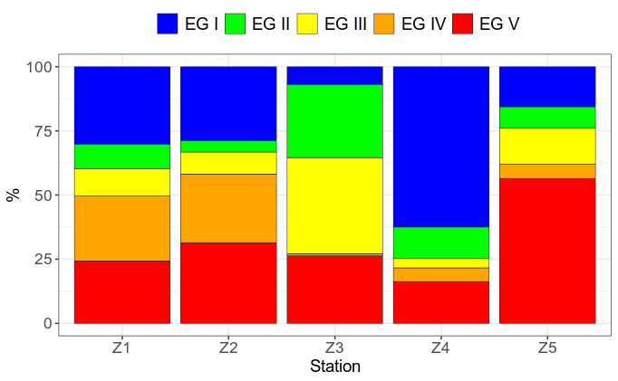

Save the plot. I think the colours are exceptionally ugly, but I suppose there’s nothing to be done, stupid standards.

```r
ggsave(filename = here(figures.dir, "eg_ambi_zostera.png"),
       plot.ambi.eg.zostera,
       dpi = 300, width = 15, height = 15, units = "cm")
```

It’s interesting that EG5 (first-order opportunists) is present everywhere in the seagrass habitats, no matter where the station is geographically (inner or outer bay) - most of all at Z5-Ropotamo. There is also a higher proportion of EG4 at the inner stations, and the highest proportion of sensitive species is at station Z4-Gradina. Not bad, for a non-adjusted index and all.

###### **BENTIX**

On to the BENTIX calculations.

|  | N | GS(%) | GT(%) | NA | BENTIX |
| --- | --- | --- | --- | --- | --- |
| Poda_1 | 437 | 4.81 | 94.97 | 0.23 | 2.188 |
| Poda_2 | 266 | 16.54 | 83.46 | 0.00 | 2.662 |
| Poda_3 | 317 | 5.36 | 94.64 | 0.00 | 2.215 |
| Poda_4 | 219 | 10.50 | 89.50 | 0.00 | 2.420 |
| Poda_5 | 136 | 43.38 | 56.62 | 0.00 | 3.735 |
| Poda_6 | 289 | 66.78 | 32.87 | 0.35 | 4.664 |
| Poda_7 | 260 | 62.69 | 34.23 | 3.08 | 4.446 |
| Poda_8 | 154 | 53.25 | 44.81 | 1.95 | 4.091 |
| Otmanli_1 | 288 | 18.40 | 81.60 | 0.00 | 2.736 |
| Otmanli_2 | 295 | 16.61 | 83.39 | 0.00 | 2.664 |

[output cut: 22 more lines]

Put all indices in one single tibble.

| station | year | month | S | H1 | AMBI | BENTIX | M-AMBI | M-AMBIn | H.EQR | AMBI.EQR | BENTIX.EQR |
| --- | --- | --- | --- | --- | --- | --- | --- | --- | --- | --- | --- |
| Poda | 2013 | 6 | 25 | 3.005 | 4.614 | 2.188 | 0.592 | 0.374 | 0.751 | 0.231 | 0.365 |
| Poda | 2013 | 6 | 25 | 3.140 | 4.336 | 2.662 | 0.592 | 0.413 | 0.785 | 0.277 | 0.444 |
| Poda | 2013 | 6 | 19 | 2.682 | 4.363 | 2.215 | 0.592 | 0.297 | 0.670 | 0.273 | 0.369 |
| Poda | 2013 | 6 | 22 | 3.014 | 4.295 | 2.420 | 0.592 | 0.372 | 0.754 | 0.284 | 0.403 |
| Poda | 2014 | 7 | 19 | 3.118 | 2.162 | 3.735 | 0.679 | 0.521 | 0.780 | 0.640 | 0.622 |
| Poda | 2014 | 7 | 22 | 2.333 | 1.500 | 4.664 | 0.679 | 0.504 | 0.583 | 0.750 | 0.777 |
| Poda | 2014 | 7 | 26 | 2.795 | 1.488 | 4.446 | 0.679 | 0.600 | 0.699 | 0.752 | 0.741 |
| Poda | 2014 | 7 | 21 | 3.080 | 1.744 | 4.091 | 0.679 | 0.568 | 0.770 | 0.709 | 0.682 |
| Otmanli | 2013 | 6 | 19 | 3.208 | 4.091 | 2.736 | 0.674 | 0.383 | 0.802 | 0.318 | 0.456 |
| Otmanli | 2013 | 6 | 28 | 3.067 | 3.992 | 2.664 | 0.674 | 0.459 | 0.767 | 0.335 | 0.444 |

[output cut: 22 more lines]

Calculate the EQRs for AMBI, BENTIX and H’.

| station | year | month | S | H1 | AMBI | BENTIX | M-AMBI | M-AMBIn | H.EQR | AMBI.EQR | BENTIX.EQR |
| --- | --- | --- | --- | --- | --- | --- | --- | --- | --- | --- | --- |
| Poda | 2013 | 6 | 25 | 3.005 | 4.614 | 2.188 | 0.592 | 0.374 | 0.751 | 0.231 | 0.365 |
| Poda | 2013 | 6 | 25 | 3.140 | 4.336 | 2.662 | 0.592 | 0.413 | 0.785 | 0.277 | 0.444 |
| Poda | 2013 | 6 | 19 | 2.682 | 4.363 | 2.215 | 0.592 | 0.297 | 0.670 | 0.273 | 0.369 |
| Poda | 2013 | 6 | 22 | 3.014 | 4.295 | 2.420 | 0.592 | 0.372 | 0.754 | 0.284 | 0.403 |
| Poda | 2014 | 7 | 19 | 3.118 | 2.162 | 3.735 | 0.679 | 0.521 | 0.780 | 0.640 | 0.622 |
| Poda | 2014 | 7 | 22 | 2.333 | 1.500 | 4.664 | 0.679 | 0.504 | 0.583 | 0.750 | 0.777 |
| Poda | 2014 | 7 | 26 | 2.795 | 1.488 | 4.446 | 0.679 | 0.600 | 0.699 | 0.752 | 0.741 |
| Poda | 2014 | 7 | 21 | 3.080 | 1.744 | 4.091 | 0.679 | 0.568 | 0.770 | 0.709 | 0.682 |
| Otmanli | 2013 | 6 | 19 | 3.208 | 4.091 | 2.736 | 0.674 | 0.383 | 0.802 | 0.318 | 0.456 |
| Otmanli | 2013 | 6 | 28 | 3.067 | 3.992 | 2.664 | 0.674 | 0.459 | 0.767 | 0.335 | 0.444 |

[output cut: 22 more lines]

###### **M-AMBIn (simplified M-AMBI)**

M-AMBIn is a simplification of M-AMBI which is only a simple average of min-max normalized values. Each biotope is supposed to have specific reference values for all component indices; however, since the seagrasses don’t have it at all, I’ll use the old M-AMBI high/bad reference values.

| station | rep | M-AMBI*(n) |
| --- | --- | --- |
| Poda | 1 | 0.374 |
| Poda | 2 | 0.413 |
| Poda | 3 | 0.297 |
| Poda | 4 | 0.372 |
| Poda | 5 | 0.521 |
| Poda | 6 | 0.504 |
| Poda | 7 | 0.600 |
| Poda | 8 | 0.568 |
| Otmanli | 1 | 0.383 |
| Otmanli | 2 | 0.459 |

[output cut: 22 more lines]

I *think* that M-AMBIn is an EQR when calculated this way, off the M-AMBI EC limits, so I’m not going to recalculate, I don’t even know how to, anyway - what limits am I to use?

Save this, finally.

| station | year | month | S | H1 | AMBI | BENTIX | M-AMBI | M-AMBIn | H.EQR | AMBI.EQR | BENTIX.EQR |
| --- | --- | --- | --- | --- | --- | --- | --- | --- | --- | --- | --- |
| Poda | 2013 | 6 | 25 | 3.005 | 4.614 | 2.188 | 0.592 | 0.374 | 0.751 | 0.231 | 0.365 |
| Poda | 2013 | 6 | 25 | 3.140 | 4.336 | 2.662 | 0.592 | 0.413 | 0.785 | 0.277 | 0.444 |
| Poda | 2013 | 6 | 19 | 2.682 | 4.363 | 2.215 | 0.592 | 0.297 | 0.670 | 0.273 | 0.369 |
| Poda | 2013 | 6 | 22 | 3.014 | 4.295 | 2.420 | 0.592 | 0.372 | 0.754 | 0.284 | 0.403 |
| Poda | 2014 | 7 | 19 | 3.118 | 2.162 | 3.735 | 0.679 | 0.521 | 0.780 | 0.640 | 0.622 |
| Poda | 2014 | 7 | 22 | 2.333 | 1.500 | 4.664 | 0.679 | 0.504 | 0.583 | 0.750 | 0.777 |
| Poda | 2014 | 7 | 26 | 2.795 | 1.488 | 4.446 | 0.679 | 0.600 | 0.699 | 0.752 | 0.741 |
| Poda | 2014 | 7 | 21 | 3.080 | 1.744 | 4.091 | 0.679 | 0.568 | 0.770 | 0.709 | 0.682 |
| Otmanli | 2013 | 6 | 19 | 3.208 | 4.091 | 2.736 | 0.674 | 0.383 | 0.802 | 0.318 | 0.456 |
| Otmanli | 2013 | 6 | 28 | 3.067 | 3.992 | 2.664 | 0.674 | 0.459 | 0.767 | 0.335 | 0.444 |

[output cut: 22 more lines]

##### Exploratory analysis

Now we’ll do some exploratory analyses & summaries on the indices.  
I’ll work mostly with the EQRs from now on (directly comparable).

```r
(ind.st.summary.zostera <- indices.all.zostera %>%
    group_by(station) %>%
    select(`M-AMBI`, `M-AMBIn`, ends_with("EQR")) %>%
    summarise_all(list(~mean(.), ~sd(.)))
)
```

| station | M-AMBI_mean | M-AMBIn_mean | H.EQR_mean | AMBI.EQR_mean | BENTIX.EQR_mean | M-AMBI_sd | M-AMBIn_sd | H.EQR_sd | AMBI.EQR_sd | BENTIX.EQR_sd |
| --- | --- | --- | --- | --- | --- | --- | --- | --- | --- | --- |
| Poda | 0.6355 | 0.456125 | 0.724000 | 0.489500 | 0.550375 | 0.04650346 | 0.10738374 | 0.06971780 | 0.24162486 | 0.173389683 |
| Otmanli | 0.7100 | 0.505125 | 0.803500 | 0.431375 | 0.530250 | 0.03848562 | 0.08635051 | 0.05854424 | 0.11709573 | 0.083076127 |
| Vromos | 0.5110 | 0.377250 | 0.660500 | 0.472250 | 0.369000 | 0.00000000 | 0.03611440 | 0.02728247 | 0.06729227 | 0.006480741 |
| Gradina | 0.8500 | 0.630500 | 0.698375 | 0.748125 | 0.747625 | 0.04810702 | 0.02937443 | 0.13112692 | 0.10490327 | 0.123335706 |
| Ropotamo | 0.6850 | 0.507750 | 0.819750 | 0.302250 | 0.451250 | 0.00000000 | 0.07696482 | 0.05969017 | 0.06692471 | 0.048561816 |